# skimage.measure

Measurement of image properties, e.g., region properties, contours.

| `approximate_polygon` | Approximate a polygonal chain with the specified tolerance. |
| --- | --- |
| `block_reduce` | Downsample image by applying function `func` to local blocks. |
| `blur_effect` | Compute a metric that indicates the strength of blur in an image (0 for no blur, 1 for maximal blur). |
| `centroid` | Return the (weighted) centroid of an image. |
| `euler_number` | Calculate the Euler characteristic in binary image. |
| `find_contours` | Find iso-valued contours in a 2D array for a given level value. |
| `grid_points_in_poly` | Test whether points on a specified grid are inside a polygon. |
| `inertia_tensor` | Compute the inertia tensor of the input image. |
| `inertia_tensor_eigvals` | Compute the eigenvalues of the inertia tensor of the image. |
| `intersection_coeff` | Fraction of a channel's segmented binary mask that overlaps with a second channel's segmented binary mask. |
| `label` | Label connected regions of an integer array. |
| `manders_coloc_coeff` | Manders' colocalization coefficient between two image channels. |
| `manders_overlap_coeff` | Manders' overlap coefficient |
| `marching_cubes` | Marching cubes algorithm to find surfaces in 3d volumetric data. |
| `mesh_surface_area` | Compute surface area, given vertices and triangular faces. |
| `moments` | Calculate all raw image moments up to a certain order. |
| `moments_central` | Calculate all central image moments up to a certain order. |
| `moments_coords` | Calculate all raw image moments up to a certain order. |
| `moments_coords_central` | Calculate all central image moments up to a certain order. |
| `moments_hu` | Calculate Hu's set of image moments (2D-only). |
| `moments_normalized` | Calculate all normalized central image moments up to a certain order. |
| `pearson_corr_coeff` | Calculate Pearson's Correlation Coefficient between pixel intensities in channels. |
| `perimeter` | Calculate total perimeter of all objects in binary image. |
| `perimeter_crofton` | Calculate total Crofton perimeter of all objects in binary image. |
| `points_in_poly` | Test whether points lie inside a polygon. |
| `profile_line` | Return the intensity profile of an image measured along a scan line. |
| `ransac` | Fit a model to data with the RANSAC (random sample consensus) algorithm. |
| `regionprops` | Measure properties of labeled image regions. |
| `regionprops_table` | Compute region properties and return them as a pandas-compatible table. |
| `shannon_entropy` | Calculate the Shannon entropy of an image. |
| `subdivide_polygon` | Subdivision of polygonal curves using B-Splines. |
| `CircleModel` | Total least squares estimator for 2D circles. |
| `EllipseModel` | Total least squares estimator for 2D ellipses. |
| `LineModelND` | Total least squares estimator for N-dimensional lines. |
| `RansacModelProtocol` | Protocol for `ransac` model class. |

**`skimage.measure.approximate_polygon(coords, tolerance)` [[source]](https://github.com/scikit-image/scikit-image/blob/v0.26.0/skimage/measure/_polygon.py#L5-L91)**

Approximate a polygonal chain with the specified tolerance.

It is based on the Douglas-Peucker algorithm.

Note that the approximated polygon is always within the convex hull of the original polygon.

**Parameters:**

**`coords(K, 2) array`**

Coordinate array.

**`tolerancefloat`**

Maximum distance from original points of polygon to approximated polygonal chain. If tolerance is 0, the original coordinate array is returned.

**Returns:**

**`coords(L, 2) array`**

Approximated polygonal chain where L <= K.

#### References

[1]

https://en.wikipedia.org/wiki/Ramer-Douglas-Peucker_algorithm

[Approximate and subdivide polygons](https://scikit-image.org/docs/0.26.x/auto_examples/edges/plot_polygon.html)

Approximate and subdivide polygons

**`skimage.measure.block_reduce(image, block_size=2, func=<function sum>, cval=0, func_kwargs=None)` [[source]](https://github.com/scikit-image/scikit-image/blob/v0.26.0/skimage/measure/block.py#L5-L94)**

Downsample image by applying function `func` to local blocks.

This function is useful for max and mean pooling, for example.

**Parameters:**

**`image(M[, …]) ndarray`**

N-dimensional input image.

**`block_sizearray_like or int`**

Array containing down-sampling integer factor along each axis. Default block_size is 2.

**`funccallable`**

Function object which is used to calculate the return value for each local block. This function must implement an `axis` parameter. Primary functions are `numpy.sum`, `numpy.min`, `numpy.max`, `numpy.mean` and `numpy.median`. See also `func_kwargs`.

**`cvalfloat`**

Constant padding value if image is not perfectly divisible by the block size.

**`func_kwargsdict`**

Keyword arguments passed to `func`. Notably useful for passing dtype argument to `np.mean`. Takes dictionary of inputs, e.g.: `func_kwargs={'dtype': np.float16})`.

**Returns:**

**`imagendarray`**

Down-sampled image with same number of dimensions as input image.

#### Examples

```
>>> from skimage.measure import block_reduce
>>> image = np.arange(3*3*4).reshape(3, 3, 4)
>>> image
array([[[ 0,  1,  2,  3],
        [ 4,  5,  6,  7],
        [ 8,  9, 10, 11]],
       [[12, 13, 14, 15],
        [16, 17, 18, 19],
        [20, 21, 22, 23]],
       [[24, 25, 26, 27],
        [28, 29, 30, 31],
        [32, 33, 34, 35]]])
>>> block_reduce(image, block_size=(3, 3, 1), func=np.mean)
array([[[16., 17., 18., 19.]]])
>>> image_max1 = block_reduce(image, block_size=(1, 3, 4), func=np.max)
>>> image_max1
array([[[11]],
       [[23]],
       [[35]]])
>>> image_max2 = block_reduce(image, block_size=(3, 1, 4), func=np.max)
>>> image_max2
array([[[27],
        [31],
        [35]]])
```

**`skimage.measure.blur_effect(image, h_size=11, channel_axis=None, reduce_func=<function max>)` [[source]](https://github.com/scikit-image/scikit-image/blob/v0.26.0/skimage/measure/_blur_effect.py#L22-L98)**

Compute a metric that indicates the strength of blur in an image (0 for no blur, 1 for maximal blur).

**Parameters:**

**`imagendarray`**

RGB or grayscale nD image. The input image is converted to grayscale before computing the blur metric.

**`h_sizeint, optional`**

Size of the re-blurring filter.

**`channel_axisint or None, optional`**

If None, the image is assumed to be grayscale (single-channel). Otherwise, this parameter indicates which axis of the array corresponds to color channels.

**`reduce_funccallable, optional`**

Function used to calculate the aggregation of blur metrics along all axes. If set to None, the entire list is returned, where the i-th element is the blur metric along the i-th axis.

**Returns:**

**`blurfloat (0 to 1) or list of floats`**

Blur metric: by default, the maximum of blur metrics along all axes.

#### Notes

`h_size` must keep the same value in order to compare results between images. Most of the time, the default size (11) is enough. This means that the metric can clearly discriminate blur up to an average 11x11 filter; if blur is higher, the metric still gives good results but its values tend towards an asymptote.

#### References

[1]

Frederique Crete, Thierry Dolmiere, Patricia Ladret, and Marina Nicolas “The blur effect: perception and estimation with a new no-reference perceptual blur metric” Proc. SPIE 6492, Human Vision and Electronic Imaging XII, 64920I (2007) https://hal.archives-ouvertes.fr/hal-00232709 [DOI:10.1117/12.702790](https://doi.org/10.1117/12.702790)

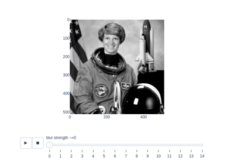

[Estimate strength of blur](https://scikit-image.org/docs/0.26.x/auto_examples/filters/plot_blur_effect.html)

Estimate strength of blur

**`skimage.measure.centroid(image, *, spacing=None)` [[source]](https://github.com/scikit-image/scikit-image/blob/v0.26.0/skimage/measure/_moments.py#L385-L414)**

Return the (weighted) centroid of an image.

**Parameters:**

**`imagearray`**

The input image.

**`spacingtuple of float, shape (ndim,)`**

The pixel spacing along each axis of the image.

**Returns:**

**`centertuple of float, length image.ndim`**

The centroid of the (nonzero) pixels in `image`.

#### Examples

```
>>> image = np.zeros((20, 20), dtype=np.float64)
>>> image[13:17, 13:17] = 0.5
>>> image[10:12, 10:12] = 1
>>> centroid(image)
array([13.16666667, 13.16666667])
```

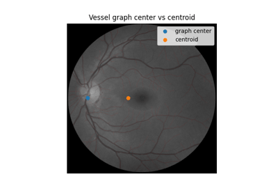

[Use pixel graphs to find an object’s geodesic center](https://scikit-image.org/docs/0.26.x/auto_examples/applications/plot_pixel_graphs.html)

Use pixel graphs to find an object's geodesic center

**`skimage.measure.euler_number(image, connectivity=None)` [[source]](https://github.com/scikit-image/scikit-image/blob/v0.26.0/skimage/measure/_regionprops_utils.py#L285-L414)**

Calculate the Euler characteristic in binary image.

For 2D objects, the Euler number is the number of objects minus the number of holes. For 3D objects, the Euler number is obtained as the number of objects plus the number of holes, minus the number of tunnels, or loops.

**Parameters:**

**`image(M, N[, P]) ndarray`**

Input image. If image is not binary, all values greater than zero are considered as the object.

**`connectivityint, optional`**

Maximum number of orthogonal hops to consider a pixel/voxel as a neighbor. Accepted values are ranging from 1 to input.ndim. If `None`, a full connectivity of `input.ndim` is used. 4 or 8 neighborhoods are defined for 2D images (connectivity 1 and 2, respectively). 6 or 26 neighborhoods are defined for 3D images, (connectivity 1 and 3, respectively). Connectivity 2 is not defined.

**Returns:**

**`euler_numberint`**

Euler characteristic of the set of all objects in the image.

#### Notes

The Euler characteristic is an integer number that describes the topology of the set of all objects in the input image. If object is 4-connected, then background is 8-connected, and conversely.

The computation of the Euler characteristic is based on an integral geometry formula in discretized space. In practice, a neighborhood configuration is constructed, and a LUT is applied for each configuration. The coefficients used are the ones of Ohser et al.

It can be useful to compute the Euler characteristic for several connectivities. A large relative difference between results for different connectivities suggests that the image resolution (with respect to the size of objects and holes) is too low.

#### References

[1]

S. Rivollier. Analyse d’image geometrique et morphometrique par diagrammes de forme et voisinages adaptatifs generaux. PhD thesis, 2010. Ecole Nationale Superieure des Mines de Saint-Etienne. https://tel.archives-ouvertes.fr/tel-00560838

[2]

Ohser J., Nagel W., Schladitz K. (2002) The Euler Number of Discretized Sets - On the Choice of Adjacency in Homogeneous Lattices. In: Mecke K., Stoyan D. (eds) Morphology of Condensed Matter. Lecture Notes in Physics, vol 600. Springer, Berlin, Heidelberg.

#### Examples

```
>>> import numpy as np
>>> import skimage as ski
>>> SAMPLE = np.zeros((100,100,100));
>>> SAMPLE[40:60, 40:60, 40:60]=1
>>> ski.measure.euler_number(SAMPLE)
1...
>>> SAMPLE[45:55,45:55,45:55] = 0;
>>> ski.measure.euler_number(SAMPLE)
2...
>>> SAMPLE = np.array([[0, 0, 0, 0, 0, 0, 0, 0, 0, 1, 0, 1, 1, 0, 0, 0, 0, 0],
...                    [0, 0, 0, 0, 0, 0, 0, 0, 1, 1, 1, 1, 0, 0, 0, 0, 0, 0],
...                    [0, 0, 0, 0, 0, 0, 0, 0, 1, 1, 1, 0, 0, 0, 0, 0, 0, 0],
...                    [0, 0, 0, 0, 0, 0, 0, 0, 1, 1, 1, 0, 0, 0, 0, 0, 0, 0],
...                    [0, 0, 0, 0, 0, 0, 1, 1, 1, 1, 1, 1, 0, 0, 0, 0, 0, 0],
...                    [0, 0, 0, 0, 0, 0, 1, 1, 1, 1, 1, 1, 1, 1, 1, 1, 1, 0],
...                    [0, 0, 0, 0, 0, 0, 1, 1, 1, 1, 1, 1, 1, 1, 1, 1, 1, 0],
...                    [1, 0, 1, 0, 0, 1, 1, 0, 1, 1, 0, 0, 1, 1, 1, 1, 1, 0],
...                    [0, 1, 1, 1, 1, 1, 1, 1, 0, 1, 1, 0, 0, 0, 1, 1, 1, 1],
...                    [0, 1, 1, 0, 0, 1, 1, 1, 0, 0, 0, 0, 0, 0, 0, 0, 1, 1]])
>>> ski.measure.euler_number(SAMPLE)
0
>>> ski.measure.euler_number(SAMPLE, connectivity=1)
2
```

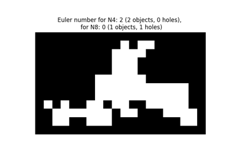

[Euler number](https://scikit-image.org/docs/0.26.x/auto_examples/segmentation/plot_euler_number.html)

Euler number

**`skimage.measure.find_contours(image, level=None, fully_connected='low', positive_orientation='low', *, mask=None)` [[source]](https://github.com/scikit-image/scikit-image/blob/v0.26.0/skimage/measure/_find_contours.py#L10-L152)**

Find iso-valued contours in a 2D array for a given level value.

Uses the “marching squares” method to compute the iso-valued contours of the input 2D array for a particular level value. Array values are linearly interpolated to provide better precision for the output contours.

**Parameters:**

**`image(M, N) ndarray of double`**

Input image in which to find contours.

**`levelfloat, optional`**

Value along which to find contours in the array. By default, the level is set to (max(image) + min(image)) / 2

Changed in version 0.18: This parameter is now optional.

**`fully_connectedstr, {‘low’, ‘high’}`**

Indicates whether array elements below the given level value are to be considered fully-connected (and hence elements above the value will only be face connected), or vice-versa. (See notes below for details.)

**`positive_orientationstr, {‘low’, ‘high’}`**

Indicates whether the output contours will produce positively-oriented polygons around islands of low- or high-valued elements. If ‘low’ then contours will wind counter-clockwise around elements below the iso-value. Alternately, this means that low-valued elements are always on the left of the contour. (See below for details.)

**`mask(M, N) ndarray of bool or None`**

A boolean mask, True where we want to draw contours. Note that NaN values are always excluded from the considered region (`mask` is set to `False` wherever `array` is `NaN`).

**Returns:**

**`contourslist of (K, 2) ndarrays`**

Each contour is a ndarray of `(row, column)` coordinates along the contour.

See also

**`skimage.measure.marching_cubes`**

#### Notes

The marching squares algorithm is a special case of the marching cubes algorithm [1]. A simple explanation is available here:

https://users.polytech.unice.fr/~lingrand/MarchingCubes/algo.html

There is a single ambiguous case in the marching squares algorithm: when a given `2 x 2`-element square has two high-valued and two low-valued elements, each pair diagonally adjacent. (Where high- and low-valued is with respect to the contour value sought.) In this case, either the high-valued elements can be ‘connected together’ via a thin isthmus that separates the low-valued elements, or vice-versa. When elements are connected together across a diagonal, they are considered ‘fully connected’ (also known as ‘face+vertex-connected’ or ‘8-connected’). Only high-valued or low-valued elements can be fully-connected, the other set will be considered as ‘face-connected’ or ‘4-connected’. By default, low-valued elements are considered fully-connected; this can be altered with the ‘fully_connected’ parameter.

Output contours are not guaranteed to be closed: contours which intersect the array edge or a masked-off region (either where mask is False or where array is NaN) will be left open. All other contours will be closed. (The closed-ness of a contours can be tested by checking whether the beginning point is the same as the end point.)

Contours are oriented. By default, array values lower than the contour value are to the left of the contour and values greater than the contour value are to the right. This means that contours will wind counter-clockwise (i.e. in ‘positive orientation’) around islands of low-valued pixels. This behavior can be altered with the ‘positive_orientation’ parameter.

The order of the contours in the output list is determined by the position of the smallest `x,y` (in lexicographical order) coordinate in the contour. This is a side effect of how the input array is traversed, but can be relied upon.

Warning

Array coordinates/values are assumed to refer to the *center* of the array element. Take a simple example input: `[0, 1]`. The interpolated position of 0.5 in this array is midway between the 0-element (at `x=0`) and the 1-element (at `x=1`), and thus would fall at `x=0.5`.

This means that to find reasonable contours, it is best to find contours midway between the expected “light” and “dark” values. In particular, given a binarized array, *do not* choose to find contours at the low or high value of the array. This will often yield degenerate contours, especially around structures that are a single array element wide. Instead, choose a middle value, as above.

#### References

[]

Lorensen, William and Harvey E. Cline. Marching Cubes: A High Resolution 3D Surface Construction Algorithm. Computer Graphics (SIGGRAPH 87 Proceedings) 21(4) July 1987, p. 163-170). [DOI:10.1145/37401.37422](https://doi.org/10.1145/37401.37422)

#### Examples

```
>>> a = np.zeros((3, 3))
>>> a[0, 0] = 1
>>> a
array([[1., 0., 0.],
       [0., 0., 0.],
       [0., 0., 0.]])
>>> find_contours(a, 0.5)
[array([[0. , 0.5],
       [0.5, 0. ]])]
```

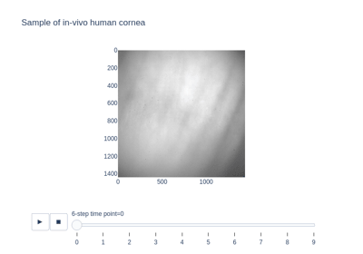

[Restore spotted cornea image with inpainting](https://scikit-image.org/docs/0.26.x/auto_examples/applications/plot_cornea_spot_inpainting.html)

Restore spotted cornea image with inpainting

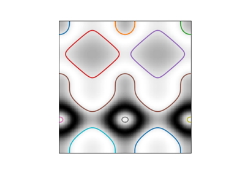

[Contour finding](https://scikit-image.org/docs/0.26.x/auto_examples/edges/plot_contours.html)

Contour finding

[Approximate and subdivide polygons](https://scikit-image.org/docs/0.26.x/auto_examples/edges/plot_polygon.html)

Approximate and subdivide polygons

[Measure region properties](https://scikit-image.org/docs/0.26.x/auto_examples/segmentation/plot_regionprops.html)

Measure region properties

**`skimage.measure.grid_points_in_poly(shape, verts, binarize=True)` [[source]](https://github.com/scikit-image/scikit-image/blob/v0.26.0/skimage/measure/pnpoly.py#L4-L43)**

Test whether points on a specified grid are inside a polygon.

For each `(r, c)` coordinate on a grid, i.e. `(0, 0)`, `(0, 1)` etc., test whether that point lies inside a polygon.

You can control the output type with the `binarize` flag. Please refer to its documentation for further details.

**Parameters:**

**`shapetuple (M, N)`**

Shape of the grid.

**`verts(V, 2) array`**

Specify the V vertices of the polygon, sorted either clockwise or anti-clockwise. The first point may (but does not need to be) duplicated.

**`binarizebool`**

If [`True`](https://docs.python.org/3/library/constants.html#True), the output of the function is a boolean mask. Otherwise, it is a labeled array. The labels are: O - outside, 1 - inside, 2 - vertex, 3 - edge.

**Returns:**

**`mask(M, N) ndarray`**

If `binarize` is True, the output is a boolean mask. True means the corresponding pixel falls inside the polygon. If `binarize` is False, the output is a labeled array, with pixels having a label between 0 and 3. The meaning of the values is: O - outside, 1 - inside, 2 - vertex, 3 - edge.

See also

**`points_in_poly`**

**`skimage.measure.inertia_tensor(image, mu=None, *, spacing=None)` [[source]](https://github.com/scikit-image/scikit-image/blob/v0.26.0/skimage/measure/_moments.py#L417-L470)**

Compute the inertia tensor of the input image.

**Parameters:**

**`imagearray`**

The input image.

**`muarray, optional`**

The pre-computed central moments of `image`. The inertia tensor computation requires the central moments of the image. If an application requires both the central moments and the inertia tensor (for example, `skimage.measure.regionprops`), then it is more efficient to pre-compute them and pass them to the inertia tensor call.

**`spacingtuple of float, shape (ndim,)`**

The pixel spacing along each axis of the image.

**Returns:**

**`Tarray, shape (image.ndim, image.ndim)`**

The inertia tensor of the input image. $T_{i, j}$ contains the covariance of image intensity along axes $i$ and $j$.

#### References

[1]

https://en.wikipedia.org/wiki/Moment_of_inertia#Inertia_tensor

[2]

Bernd Jähne. Spatio-Temporal Image Processing: Theory and Scientific Applications. (Chapter 8: Tensor Methods) Springer, 1993.

**`skimage.measure.inertia_tensor_eigvals(image, mu=None, T=None, *, spacing=None)` [[source]](https://github.com/scikit-image/scikit-image/blob/v0.26.0/skimage/measure/_moments.py#L473-L513)**

Compute the eigenvalues of the inertia tensor of the image.

The inertia tensor measures covariance of the image intensity along the image axes. (See `inertia_tensor`.) The relative magnitude of the eigenvalues of the tensor is thus a measure of the elongation of a (bright) object in the image.

**Parameters:**

**`imagearray`**

The input image.

**`muarray, optional`**

The pre-computed central moments of `image`.

**`Tarray, shape (image.ndim, image.ndim)`**

The pre-computed inertia tensor. If `T` is given, `mu` and `image` are ignored.

**`spacingtuple of float, shape (ndim,)`**

The pixel spacing along each axis of the image.

**Returns:**

**`eigvalslist of float, length image.ndim`**

The eigenvalues of the inertia tensor of `image`, in descending order.

#### Notes

Computing the eigenvalues requires the inertia tensor of the input image. This is much faster if the central moments (`mu`) are provided, or, alternatively, one can provide the inertia tensor (`T`) directly.

**`skimage.measure.intersection_coeff(image0_mask, image1_mask, mask=None)` [[source]](https://github.com/scikit-image/scikit-image/blob/v0.26.0/skimage/measure/_colocalization.py#L268-L305)**

Fraction of a channel’s segmented binary mask that overlaps with a second channel’s segmented binary mask.

**Parameters:**

**`image0_mask(M, N) ndarray of dtype bool`**

Image mask of channel A.

**`image1_mask(M, N) ndarray of dtype bool`**

Image mask of channel B. Must have same dimensions as `image0_mask`.

**`mask(M, N) ndarray of dtype bool, optional`**

Only `image0_mask` and `image1_mask` pixels within this region of interest mask are included in the calculation. Must have same dimensions as `image0_mask`.

**Returns:**

**Intersection coefficient, float**

Fraction of `image0_mask` that overlaps with `image1_mask`.

[Colocalization metrics](https://scikit-image.org/docs/0.26.x/auto_examples/applications/plot_colocalization_metrics.html)

Colocalization metrics

**`skimage.measure.label(label_image, background=None, return_num=False, connectivity=None)` [[source]](https://github.com/scikit-image/scikit-image/blob/v0.26.0/skimage/measure/_label.py#L33-L125)**

Label connected regions of an integer array.

Two pixels are connected when they are neighbors and have the same value. In 2D, they can be neighbors either in a 1- or 2-connected sense. The value refers to the maximum number of orthogonal hops to consider a pixel/voxel a neighbor:

```
1-connectivity     2-connectivity     diagonal connection close-up

     [ ]           [ ]  [ ]  [ ]             [ ]
      |               \  |  /                 |  <- hop 2
[ ]--[x]--[ ]      [ ]--[x]--[ ]        [x]--[ ]
      |               /  |  \             hop 1
     [ ]           [ ]  [ ]  [ ]
```

**Parameters:**

**`label_imagendarray of dtype int`**

Image to label.

**`backgroundint, optional`**

Consider all pixels with this value as background pixels, and label them as 0. By default, 0-valued pixels are considered as background pixels.

**`return_numbool, optional`**

Whether to return the number of assigned labels.

**`connectivityint, optional`**

Maximum number of orthogonal hops to consider a pixel/voxel as a neighbor. Accepted values are ranging from 1 to input.ndim. If `None`, a full connectivity of `input.ndim` is used.

**Returns:**

**`labelsndarray of dtype int`**

Labeled array, where all connected regions are assigned the same integer value.

**`numint, optional`**

Number of labels, which equals the maximum label index and is only returned if return_num is [`True`](https://docs.python.org/3/library/constants.html#True).

See also

**`skimage.measure.regionprops`**

**`skimage.measure.regionprops_table`**

#### References

[1]

Christophe Fiorio and Jens Gustedt, “Two linear time Union-Find strategies for image processing”, Theoretical Computer Science 154 (1996), pp. 165-181.

[2]

Kensheng Wu, Ekow Otoo and Arie Shoshani, “Optimizing connected component labeling algorithms”, Paper LBNL-56864, 2005, Lawrence Berkeley National Laboratory (University of California), http://repositories.cdlib.org/lbnl/LBNL-56864

#### Examples

```
>>> import numpy as np
>>> x = np.eye(3).astype(int)
>>> print(x)
[[1 0 0]
 [0 1 0]
 [0 0 1]]
>>> print(label(x, connectivity=1))
[[1 0 0]
 [0 2 0]
 [0 0 3]]
>>> print(label(x, connectivity=2))
[[1 0 0]
 [0 1 0]
 [0 0 1]]
>>> print(label(x, background=-1))
[[1 2 2]
 [2 1 2]
 [2 2 1]]
>>> x = np.array([[1, 0, 0],
...               [1, 1, 5],
...               [0, 0, 0]])
>>> print(label(x))
[[1 0 0]
 [1 1 2]
 [0 0 0]]
```

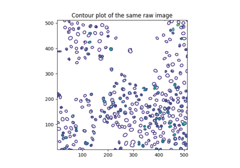

[Segment human cells (in mitosis)](https://scikit-image.org/docs/0.26.x/auto_examples/applications/plot_human_mitosis.html)

Segment human cells (in mitosis)

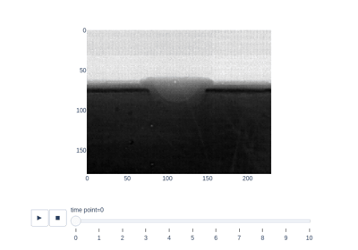

[Track solidification of a metallic alloy](https://scikit-image.org/docs/0.26.x/auto_examples/applications/plot_solidification_tracking.html)

Track solidification of a metallic alloy

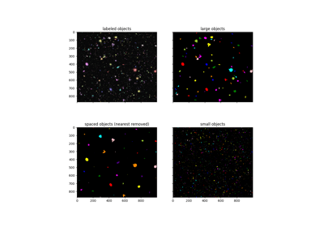

[Removing objects](https://scikit-image.org/docs/0.26.x/auto_examples/features_detection/plot_remove_objects.html)

Removing objects

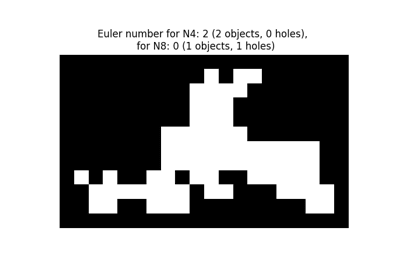

[Euler number](https://scikit-image.org/docs/0.26.x/auto_examples/segmentation/plot_euler_number.html)

Euler number

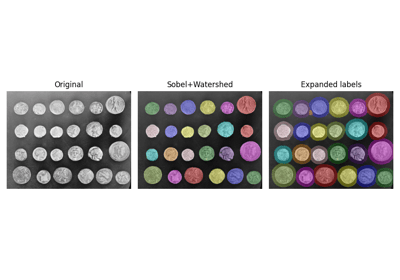

[Expand segmentation labels without overlap](https://scikit-image.org/docs/0.26.x/auto_examples/segmentation/plot_expand_labels.html)

Expand segmentation labels without overlap

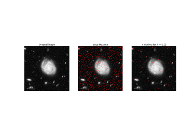

[Extrema](https://scikit-image.org/docs/0.26.x/auto_examples/segmentation/plot_extrema.html)

Extrema

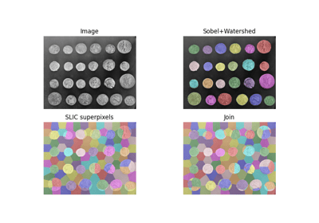

[Find the intersection of two segmentations](https://scikit-image.org/docs/0.26.x/auto_examples/segmentation/plot_join_segmentations.html)

Find the intersection of two segmentations

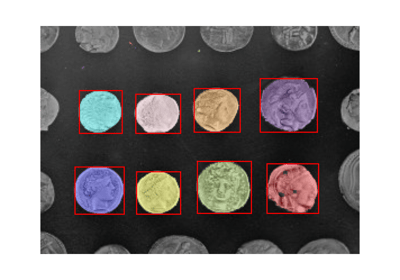

[Label image regions](https://scikit-image.org/docs/0.26.x/auto_examples/segmentation/plot_label.html)

Label image regions

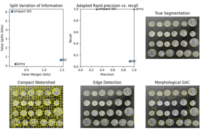

[Evaluating segmentation metrics](https://scikit-image.org/docs/0.26.x/auto_examples/segmentation/plot_metrics.html)

Evaluating segmentation metrics

[Measure region properties](https://scikit-image.org/docs/0.26.x/auto_examples/segmentation/plot_regionprops.html)

Measure region properties

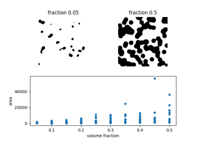

[Explore and visualize region properties with pandas](https://scikit-image.org/docs/0.26.x/auto_examples/segmentation/plot_regionprops_table.html)

Explore and visualize region properties with pandas

**`skimage.measure.manders_coloc_coeff(image0, image1_mask, mask=None)` [[source]](https://github.com/scikit-image/scikit-image/blob/v0.26.0/skimage/measure/_colocalization.py#L100-L180)**

Manders’ colocalization coefficient between two image channels.

**Parameters:**

**`image0(M, N) ndarray`**

Input image (first channel). All pixel values should be non-negative.

**`image1_mask(M, N) ndarray of dtype bool`**

Binary image giving the regions of interest in the second channel. Must have same shape as `image0`.

**`mask(M, N) ndarray of dtype bool, optional`**

Only `image0` pixel values within `mask` are included in the calculation. Must have same shape as `image0`.

**Returns:**

**`mccfloat`**

Manders’ colocalization coefficient.

#### Notes

Manders’ colocalization coefficient (MCC) was developed in the context of confocal biological microscopy, to measure the fraction of colocalizing objects in each component of a dual-channel image. Out of the total intensity of, say, channel A, how much is found within the features (objects) of, say, channel B [1]? The measure thus ranges from 0 for no colocalization to 1 for complete colocalization.

MCC is commonly used to measure the colocalization of a particular protein in a subcelullar compartment. Typically, the mask for channel B is obtained by thresholding, to segment the features from the background. In this implementation, channel B is passed directly as a mask (`image1_mask`), leaving the segmentation step to the user (upstream).

The implemented equation is:

$mcc = \frac{\sum_i A_{i,coloc}}{\sum_i A_i}$

where

- $A_i$ is the value of the $i^{th}$ pixel in `image0`, and
- $A_{i, coloc} = A_i B_i$, considering that $B_i$ is the (`True` or `False`) value of the $i^{th}$ pixel in `image1_mask` cast into int or float (`1` or `0`, respectively).

MCC is sensitive to noise, with diffuse signal in the first channel inflating its value. Therefore, images should be processed beforehand to remove out-of-focus and background light [2].

#### References

[]

Manders, E.M.M., Verbeek, F.J. and Aten, J.A. (1993), Measurement of co-localization of objects in dual-colour confocal images. Journal of Microscopy, 169: 375-382. https://doi.org/10.1111/j.1365-2818.1993.tb03313.x https://imagej.net/media/manders.pdf

[]

Dunn, K. W., Kamocka, M. M., & McDonald, J. H. (2011). A practical guide to evaluating colocalization in biological microscopy. American journal of physiology. Cell physiology, 300(4), C723–C742. https://doi.org/10.1152/ajpcell.00462.2010

[Colocalization metrics](https://scikit-image.org/docs/0.26.x/auto_examples/applications/plot_colocalization_metrics.html)

Colocalization metrics

**`skimage.measure.manders_overlap_coeff(image0, image1, mask=None)` [[source]](https://github.com/scikit-image/scikit-image/blob/v0.26.0/skimage/measure/_colocalization.py#L183-L265)**

Manders’ overlap coefficient

**Parameters:**

**`image0(M, N) ndarray`**

Image of channel A. All pixel values should be non-negative.

**`image1(M, N) ndarray`**

Image of channel B. All pixel values should be non-negative. Must have same dimensions as `image0`

**`mask(M, N) ndarray of dtype bool, optional`**

**Returns:**

**moc: float**

Manders’ Overlap Coefficient of pixel intensities between the two images.

#### Notes

Manders’ Overlap Coefficient (MOC) is given by the equation [1]:

$r = \frac{\sum A_i B_i}{\sqrt{\sum A_i^2 \sum B_i^2}}$

**where**

$A_i$ is the value of the $i^{th}$ pixel in `image0` $B_i$ is the value of the $i^{th}$ pixel in `image1`

It ranges between 0 for no colocalization and 1 for complete colocalization of all pixels.

#### References

[]

Manders, E.M.M., Verbeek, F.J. and Aten, J.A. (1993), Measurement of co-localization of objects in dual-colour confocal images. Journal of Microscopy, 169: 375-382. https://doi.org/10.1111/j.1365-2818.1993.tb03313.x https://imagej.net/media/manders.pdf

[2]

Dunn, K. W., Kamocka, M. M., & McDonald, J. H. (2011). A practical guide to evaluating colocalization in biological microscopy. American journal of physiology. Cell physiology, 300(4), C723–C742. https://doi.org/10.1152/ajpcell.00462.2010

[]

[]

Adler J, Parmryd I. (2010), Quantifying colocalization by correlation: the Pearson correlation coefficient is superior to the Mander’s overlap coefficient. Cytometry A. Aug;77(8):733-42.https://doi.org/10.1002/cyto.a.20896

[]

Adler, J, Parmryd, I. Quantifying colocalization: The case for discarding the Manders overlap coefficient. Cytometry. 2021; 99: 910– 920. https://doi.org/10.1002/cyto.a.24336

**`skimage.measure.marching_cubes(volume, level=None, *, spacing=(1.0, 1.0, 1.0), gradient_direction='descent', step_size=1, allow_degenerate=True, method='lewiner', mask=None)` [[source]](https://github.com/scikit-image/scikit-image/blob/v0.26.0/skimage/measure/_marching_cubes_lewiner.py#L9-L148)**

Marching cubes algorithm to find surfaces in 3d volumetric data.

In contrast with Lorensen et al. approach [2], Lewiner et al. algorithm is faster, resolves ambiguities, and guarantees topologically correct results. Therefore, this algorithm generally a better choice.

**Parameters:**

**`volume(M, N, P) ndarray`**

Input data volume to find isosurfaces. Will internally be converted to float32 if necessary.

**`levelfloat, optional`**

Contour value to search for isosurfaces in `volume`. If not given or None, the average of the min and max of vol is used.

**`spacinglength-3 tuple of floats, optional`**

Voxel spacing in spatial dimensions corresponding to numpy array indexing dimensions (M, N, P) as in `volume`.

**`gradient_direction{‘descent’, ‘ascent’}, optional`**

Controls if the mesh was generated from an isosurface with gradient descent toward objects of interest (the default), or the opposite, considering the *left-hand* rule. The two options are: * descent : Object was greater than exterior * ascent : Exterior was greater than object

**`step_sizeint, optional`**

Step size in voxels. Default 1. Larger steps yield faster but coarser results. The result will always be topologically correct though.

**`allow_degeneratebool, optional`**

Whether to allow degenerate (i.e. zero-area) triangles in the end-result. Default True. If False, degenerate triangles are removed, at the cost of making the algorithm slower.

**`method{‘lewiner’, ‘lorensen’}, optional`**

Whether the method of Lewiner et al. or Lorensen et al. will be used.

**`mask(M, N, P) array, optional`**

Boolean array. The marching cube algorithm will be computed only on True elements. This will save computational time when interfaces are located within certain region of the volume M, N, P-e.g. the top half of the cube-and also allow to compute finite surfaces-i.e. open surfaces that do not end at the border of the cube.

**Returns:**

**`verts(V, 3) array`**

Spatial coordinates for V unique mesh vertices. Coordinate order matches input `volume` (M, N, P). If `allow_degenerate` is set to True, then the presence of degenerate triangles in the mesh can make this array have duplicate vertices.

**`faces(F, 3) array`**

Define triangular faces via referencing vertex indices from `verts`. This algorithm specifically outputs triangles, so each face has exactly three indices.

**`normals(V, 3) array`**

The normal direction at each vertex, as calculated from the data.

**`values(V,) array`**

Gives a measure for the maximum value of the data in the local region near each vertex. This can be used by visualization tools to apply a colormap to the mesh.

See also

**`skimage.measure.mesh_surface_area`**

**`skimage.measure.find_contours`**

#### Notes

The algorithm [1] is an improved version of Chernyaev’s Marching Cubes 33 algorithm. It is an efficient algorithm that relies on heavy use of lookup tables to handle the many different cases, keeping the algorithm relatively easy. This implementation is written in Cython, ported from Lewiner’s C++ implementation.

To quantify the area of an isosurface generated by this algorithm, pass verts and faces to `skimage.measure.mesh_surface_area`.

Regarding visualization of algorithm output, to contour a volume named `myvolume` about the level 0.0, using the `mayavi` package:

```
>>>
>> from mayavi import mlab
>> verts, faces, _, _ = marching_cubes(myvolume, 0.0)
>> mlab.triangular_mesh([vert[0] for vert in verts],
                        [vert[1] for vert in verts],
                        [vert[2] for vert in verts],
                        faces)
>> mlab.show()
```

Similarly using the `visvis` package:

```
>>>
>> import visvis as vv
>> verts, faces, normals, values = marching_cubes(myvolume, 0.0)
>> vv.mesh(np.fliplr(verts), faces, normals, values)
>> vv.use().Run()
```

To reduce the number of triangles in the mesh for better performance, see this [example](https://docs.enthought.com/mayavi/mayavi/auto/example_julia_set_decimation.html#example-julia-set-decimation) using the `mayavi` package.

#### References

[]

Thomas Lewiner, Helio Lopes, Antonio Wilson Vieira and Geovan Tavares. Efficient implementation of Marching Cubes’ cases with topological guarantees. Journal of Graphics Tools 8(2) pp. 1-15 (december 2003). [DOI:10.1080/10867651.2003.10487582](https://doi.org/10.1080/10867651.2003.10487582)

[]

Lorensen, William and Harvey E. Cline. Marching Cubes: A High Resolution 3D Surface Construction Algorithm. Computer Graphics (SIGGRAPH 87 Proceedings) 21(4) July 1987, p. 163-170). [DOI:10.1145/37401.37422](https://doi.org/10.1145/37401.37422)

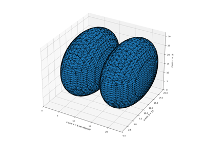

[Marching Cubes](https://scikit-image.org/docs/0.26.x/auto_examples/edges/plot_marching_cubes.html)

Marching Cubes

**`skimage.measure.mesh_surface_area(verts, faces)` [[source]](https://github.com/scikit-image/scikit-image/blob/v0.26.0/skimage/measure/_marching_cubes_lewiner.py#L315-L352)**

Compute surface area, given vertices and triangular faces.

**Parameters:**

**`verts(V, 3) array of floats`**

Array containing coordinates for V unique mesh vertices.

**`faces(F, 3) array of ints`**

List of length-3 lists of integers, referencing vertex coordinates as provided in `verts`.

**Returns:**

**`areafloat`**

Surface area of mesh. Units now [coordinate units] ** 2.

See also

**`skimage.measure.marching_cubes`**

#### Notes

The arguments expected by this function are the first two outputs from `skimage.measure.marching_cubes`. For unit correct output, ensure correct `spacing` was passed to `skimage.measure.marching_cubes`.

This algorithm works properly only if the `faces` provided are all triangles.

**`skimage.measure.moments(image, order=3, *, spacing=None)` [[source]](https://github.com/scikit-image/scikit-image/blob/v0.26.0/skimage/measure/_moments.py#L154-L198)**

Calculate all raw image moments up to a certain order.

**The following properties can be calculated from raw image moments:**

- Area as: `M[0, 0]`.
- Centroid as: {`M[1, 0] / M[0, 0]`, `M[0, 1] / M[0, 0]`}.

Note that raw moments are neither translation, scale nor rotation invariant.

**Parameters:**

**`image(N[, …]) double or uint8 array`**

Rasterized shape as image.

**`orderint, optional`**

Maximum order of moments. Default is 3.

**`spacingtuple of float, shape (ndim,)`**

The pixel spacing along each axis of the image.

**Returns:**

**`m(order + 1, order + 1) array`**

Raw image moments.

#### References

[1]

Wilhelm Burger, Mark Burge. Principles of Digital Image Processing: Core Algorithms. Springer-Verlag, London, 2009.

[2]

B. Jähne. Digital Image Processing. Springer-Verlag, Berlin-Heidelberg, 6. edition, 2005.

[3]

T. H. Reiss. Recognizing Planar Objects Using Invariant Image Features, from Lecture notes in computer science, p. 676. Springer, Berlin, 1993.

[4]

https://en.wikipedia.org/wiki/Image_moment

#### Examples

```
>>> image = np.zeros((20, 20), dtype=np.float64)
>>> image[13:17, 13:17] = 1
>>> M = moments(image)
>>> centroid = (M[1, 0] / M[0, 0], M[0, 1] / M[0, 0])
>>> centroid
(14.5, 14.5)
```

**`skimage.measure.moments_central(image, center=None, order=3, *, spacing=None, **kwargs)` [[source]](https://github.com/scikit-image/scikit-image/blob/v0.26.0/skimage/measure/_moments.py#L201-L277)**

Calculate all central image moments up to a certain order.

The center coordinates (cr, cc) can be calculated from the raw moments as: {`M[1, 0] / M[0, 0]`, `M[0, 1] / M[0, 0]`}.

Note that central moments are translation invariant but not scale and rotation invariant.

**Parameters:**

**`image(N[, …]) double or uint8 array`**

Rasterized shape as image.

**`centertuple of float, optional`**

Coordinates of the image centroid. This will be computed if it is not provided.

**`orderint, optional`**

The maximum order of moments computed.

**`spacingtuple of float, shape (ndim,)`**

The pixel spacing along each axis of the image.

**Returns:**

**`mu(order + 1, order + 1) array`**

Central image moments.

#### References

[1]

Wilhelm Burger, Mark Burge. Principles of Digital Image Processing: Core Algorithms. Springer-Verlag, London, 2009.

[2]

B. Jähne. Digital Image Processing. Springer-Verlag, Berlin-Heidelberg, 6. edition, 2005.

[3]

T. H. Reiss. Recognizing Planar Objects Using Invariant Image Features, from Lecture notes in computer science, p. 676. Springer, Berlin, 1993.

[4]

https://en.wikipedia.org/wiki/Image_moment

#### Examples

```
>>> image = np.zeros((20, 20), dtype=np.float64)
>>> image[13:17, 13:17] = 1
>>> M = moments(image)
>>> centroid = (M[1, 0] / M[0, 0], M[0, 1] / M[0, 0])
>>> moments_central(image, centroid)
array([[16.,  0., 20.,  0.],
       [ 0.,  0.,  0.,  0.],
       [20.,  0., 25.,  0.],
       [ 0.,  0.,  0.,  0.]])
```

**`skimage.measure.moments_coords(coords, order=3)` [[source]](https://github.com/scikit-image/scikit-image/blob/v0.26.0/skimage/measure/_moments.py#L10-L48)**

Calculate all raw image moments up to a certain order.

**The following properties can be calculated from raw image moments:**

- Area as: `M[0, 0]`.
- Centroid as: {`M[1, 0] / M[0, 0]`, `M[0, 1] / M[0, 0]`}.

Note that raw moments are neither translation, scale, nor rotation invariant.

**Parameters:**

**`coords(N, D) double or uint8 array`**

Array of N points that describe an image of D dimensionality in Cartesian space.

**`orderint, optional`**

Maximum order of moments. Default is 3.

**Returns:**

**`M(order + 1, order + 1, …) array`**

Raw image moments. (D dimensions)

#### References

[1]

Johannes Kilian. Simple Image Analysis By Moments. Durham University, version 0.2, Durham, 2001.

#### Examples

```
>>> coords = np.array([[ row, col]
...                    for row in range(13, 17)
...                    for col in range(14, 18)], dtype=np.float64)
>>> M = moments_coords(coords)
>>> centroid = (M[1, 0] / M[0, 0], M[0, 1] / M[0, 0])
>>> centroid
(14.5, 15.5)
```

**`skimage.measure.moments_coords_central(coords, center=None, order=3)` [[source]](https://github.com/scikit-image/scikit-image/blob/v0.26.0/skimage/measure/_moments.py#L51-L151)**

Calculate all central image moments up to a certain order.

**The following properties can be calculated from raw image moments:**

- Area as: `M[0, 0]`.
- Centroid as: {`M[1, 0] / M[0, 0]`, `M[0, 1] / M[0, 0]`}.

Note that raw moments are neither translation, scale nor rotation invariant.

**Parameters:**

**`coords(N, D) double or uint8 array`**

Array of N points that describe an image of D dimensionality in Cartesian space. A tuple of coordinates as returned by `np.nonzero` is also accepted as input.

**`centertuple of float, optional`**

Coordinates of the image centroid. This will be computed if it is not provided.

**`orderint, optional`**

Maximum order of moments. Default is 3.

**Returns:**

**`Mc(order + 1, order + 1, …) array`**

Central image moments. (D dimensions)

#### References

[1]

Johannes Kilian. Simple Image Analysis By Moments. Durham University, version 0.2, Durham, 2001.

#### Examples

```
>>> coords = np.array([[ row, col]
...                    for row in range(13, 17)
...                    for col in range(14, 18)])
>>> moments_coords_central(coords)
array([[16.,  0., 20.,  0.],
       [ 0.,  0.,  0.,  0.],
       [20.,  0., 25.,  0.],
       [ 0.,  0.,  0.,  0.]])
```

As seen above, for symmetric objects, odd-order moments (columns 1 and 3, rows 1 and 3) are zero when centered on the centroid, or center of mass, of the object (the default). If we break the symmetry by adding a new point, this no longer holds:

```
>>> coords2 = np.concatenate((coords, [[17, 17]]), axis=0)
>>> np.round(moments_coords_central(coords2),
...          decimals=2)
array([[17.  ,  0.  , 22.12, -2.49],
       [ 0.  ,  3.53,  1.73,  7.4 ],
       [25.88,  6.02, 36.63,  8.83],
       [ 4.15, 19.17, 14.8 , 39.6 ]])
```

Image moments and central image moments are equivalent (by definition) when the center is (0, 0):

```
>>> np.allclose(moments_coords(coords),
...             moments_coords_central(coords, (0, 0)))
True
```

**`skimage.measure.moments_hu(nu)` [[source]](https://github.com/scikit-image/scikit-image/blob/v0.26.0/skimage/measure/_moments.py#L342-L382)**

Calculate Hu’s set of image moments (2D-only).

Note that this set of moments is proved to be translation, scale and rotation invariant.

**Parameters:**

**`nu(M, M) array`**

Normalized central image moments, where M must be >= 4.

**Returns:**

**`nu(7,) array`**

Hu’s set of image moments.

#### References

[1]

M. K. Hu, “Visual Pattern Recognition by Moment Invariants”, IRE Trans. Info. Theory, vol. IT-8, pp. 179-187, 1962

[2]

Wilhelm Burger, Mark Burge. Principles of Digital Image Processing: Core Algorithms. Springer-Verlag, London, 2009.

[3]

B. Jähne. Digital Image Processing. Springer-Verlag, Berlin-Heidelberg, 6. edition, 2005.

[4]

T. H. Reiss. Recognizing Planar Objects Using Invariant Image Features, from Lecture notes in computer science, p. 676. Springer, Berlin, 1993.

[5]

https://en.wikipedia.org/wiki/Image_moment

#### Examples

```
>>> image = np.zeros((20, 20), dtype=np.float64)
>>> image[13:17, 13:17] = 0.5
>>> image[10:12, 10:12] = 1
>>> mu = moments_central(image)
>>> nu = moments_normalized(mu)
>>> np.round(moments_hu(nu), 4)
array([0.7454, 0.3512, 0.104 , 0.0406, 0.0026, 0.0241, 0.    ])
```

**`skimage.measure.moments_normalized(mu, order=3, spacing=None)` [[source]](https://github.com/scikit-image/scikit-image/blob/v0.26.0/skimage/measure/_moments.py#L280-L339)**

Calculate all normalized central image moments up to a certain order.

Note that normalized central moments are translation and scale invariant but not rotation invariant.

**Parameters:**

**`mu(M[, …], M) array`**

Central image moments, where M must be greater than or equal to `order`.

**`orderint, optional`**

Maximum order of moments. Default is 3.

**`spacingtuple of float, shape (ndim,)`**

The pixel spacing along each axis of the image.

**Returns:**

**`` nu(order + 1``[, ...], ``order + 1) array ``**

Normalized central image moments.

#### References

[1]

Wilhelm Burger, Mark Burge. Principles of Digital Image Processing: Core Algorithms. Springer-Verlag, London, 2009.

[2]

B. Jähne. Digital Image Processing. Springer-Verlag, Berlin-Heidelberg, 6. edition, 2005.

[3]

T. H. Reiss. Recognizing Planar Objects Using Invariant Image Features, from Lecture notes in computer science, p. 676. Springer, Berlin, 1993.

[4]

https://en.wikipedia.org/wiki/Image_moment

#### Examples

```
>>> image = np.zeros((20, 20), dtype=np.float64)
>>> image[13:17, 13:17] = 1
>>> m = moments(image)
>>> centroid = (m[0, 1] / m[0, 0], m[1, 0] / m[0, 0])
>>> mu = moments_central(image, centroid)
>>> moments_normalized(mu)
array([[       nan,        nan, 0.078125  , 0.        ],
       [       nan, 0.        , 0.        , 0.        ],
       [0.078125  , 0.        , 0.00610352, 0.        ],
       [0.        , 0.        , 0.        , 0.        ]])
```

**`skimage.measure.pearson_corr_coeff(image0, image1, mask=None)` [[source]](https://github.com/scikit-image/scikit-image/blob/v0.26.0/skimage/measure/_colocalization.py#L14-L97)**

Calculate Pearson’s Correlation Coefficient between pixel intensities in channels.

**Parameters:**

**`image0(M, N) ndarray`**

Image of channel A.

**`image1(M, N) ndarray`**

Image of channel 2 to be correlated with channel B. Must have same dimensions as `image0`.

**`mask(M, N) ndarray of dtype bool, optional`**

Only `image0` and `image1` pixels within this region of interest mask are included in the calculation. Must have same dimensions as `image0`.

**Returns:**

**`pccfloat`**

Pearson’s correlation coefficient of the pixel intensities between the two images, within the mask if provided.

**`p-valuefloat`**

Two-tailed p-value.

#### Notes

Pearson’s Correlation Coefficient (PCC) measures the linear correlation between the pixel intensities of the two images. Its value ranges from -1 for perfect linear anti-correlation to +1 for perfect linear correlation. The calculation of the p-value assumes that the intensities of pixels in each input image are normally distributed.

Scipy’s implementation of Pearson’s correlation coefficient is used. Please refer to it for further information and caveats [1].

$r = \frac{\sum (A_i - m_A_i) (B_i - m_B_i)} {\sqrt{\sum (A_i - m_A_i)^2 \sum (B_i - m_B_i)^2}}$

**where**

$A_i$ is the value of the $i^{th}$ pixel in `image0` $B_i$ is the value of the $i^{th}$ pixel in `image1`, $m_A_i$ is the mean of the pixel values in `image0` $m_B_i$ is the mean of the pixel values in `image1`

A low PCC value does not necessarily mean that there is no correlation between the two channel intensities, just that there is no linear correlation. You may wish to plot the pixel intensities of each of the two channels in a 2D scatterplot and use Spearman’s rank correlation if a non-linear correlation is visually identified [2]. Also consider if you are interested in correlation or co-occurence, in which case a method involving segmentation masks (e.g. MCC or intersection coefficient) may be more suitable [3] [4].

Providing the mask of only relevant sections of the image (e.g., cells, or particular cellular compartments) and removing noise is important as the PCC is sensitive to these measures [3] [4].

#### References

[]

https://docs.scipy.org/doc/scipy/reference/generated/scipy.stats.pearsonr.html

[]

https://docs.scipy.org/doc/scipy/reference/generated/scipy.stats.spearmanr.html

[3] (,)

Dunn, K. W., Kamocka, M. M., & McDonald, J. H. (2011). A practical guide to evaluating colocalization in biological microscopy. American journal of physiology. Cell physiology, 300(4), C723–C742. https://doi.org/10.1152/ajpcell.00462.2010

[4] (,)

Bolte, S. and Cordelières, F.P. (2006), A guided tour into subcellular colocalization analysis in light microscopy. Journal of Microscopy, 224: 213-232. https://doi.org/10.1111/j.1365-2818.2006.01706.x

[Colocalization metrics](https://scikit-image.org/docs/0.26.x/auto_examples/applications/plot_colocalization_metrics.html)

Colocalization metrics

**`skimage.measure.perimeter(image, neighborhood=4)` [[source]](https://github.com/scikit-image/scikit-image/blob/v0.26.0/skimage/measure/_regionprops_utils.py#L417-L481)**

Calculate total perimeter of all objects in binary image.

**Parameters:**

**`image(M, N) ndarray`**

Binary input image.

**`neighborhood4 or 8, optional`**

Neighborhood connectivity for border pixel determination. It is used to compute the contour. A higher neighborhood widens the border on which the perimeter is computed.

**Returns:**

**`perimeterfloat`**

Total perimeter of all objects in binary image.

#### References

[1]

K. Benkrid, D. Crookes. Design and FPGA Implementation of a Perimeter Estimator. The Queen’s University of Belfast. http://www.cs.qub.ac.uk/~d.crookes/webpubs/papers/perimeter.doc

#### Examples

```
>>> import skimage as ski
>>> # coins image (binary)
>>> img_coins = ski.data.coins() > 110
>>> # total perimeter of all objects in the image
>>> ski.measure.perimeter(img_coins, neighborhood=4)
7796.867...
>>> ski.measure.perimeter(img_coins, neighborhood=8)
8806.268...
```

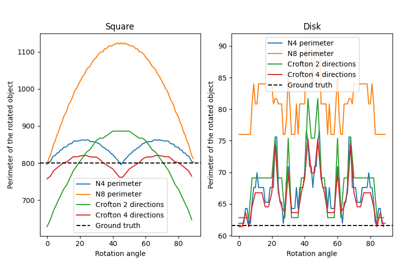

[Measure perimeters with different estimators](https://scikit-image.org/docs/0.26.x/auto_examples/segmentation/plot_perimeters.html)

Measure perimeters with different estimators

**`skimage.measure.perimeter_crofton(image, directions=4)` [[source]](https://github.com/scikit-image/scikit-image/blob/v0.26.0/skimage/measure/_regionprops_utils.py#L484-L586)**

Calculate total Crofton perimeter of all objects in binary image.

**Parameters:**

**`image(M, N) ndarray`**

Input image. If image is not binary, all values greater than zero are considered as the object.

**`directions2 or 4, optional`**

Number of directions used to approximate the Crofton perimeter. By default, 4 is used: it should be more accurate than 2. Computation time is the same in both cases.

**Returns:**

**`perimeterfloat`**

Total perimeter of all objects in binary image.

#### Notes

This measure is based on Crofton formula [1], which is a measure from integral geometry. It is defined for general curve length evaluation via a double integral along all directions. In a discrete space, 2 or 4 directions give a quite good approximation, 4 being more accurate than 2 for more complex shapes.

Similar to `perimeter()`, this function returns an approximation of the perimeter in continuous space.

#### References

[1]

https://en.wikipedia.org/wiki/Crofton_formula

[2]

S. Rivollier. Analyse d’image geometrique et morphometrique par diagrammes de forme et voisinages adaptatifs generaux. PhD thesis, 2010. Ecole Nationale Superieure des Mines de Saint-Etienne. https://tel.archives-ouvertes.fr/tel-00560838

#### Examples

```
>>> import skimage as ski
>>> # coins image (binary)
>>> img_coins = ski.data.coins() > 110
>>> # total perimeter of all objects in the image
>>> ski.measure.perimeter_crofton(img_coins, directions=2)
8144.578...
>>> ski.measure.perimeter_crofton(img_coins, directions=4)
7837.077...
```

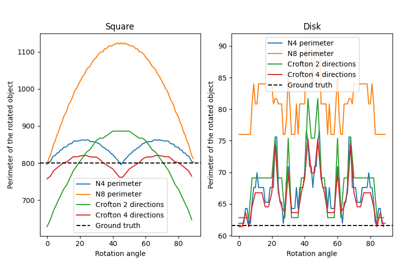

[Measure perimeters with different estimators](https://scikit-image.org/docs/0.26.x/auto_examples/segmentation/plot_perimeters.html)

Measure perimeters with different estimators

**`skimage.measure.points_in_poly(points, verts)` [[source]](https://github.com/scikit-image/scikit-image/blob/v0.26.0/skimage/measure/pnpoly.py#L46-L67)**

Test whether points lie inside a polygon.

**Parameters:**

**`points(K, 2) array`**

Input points, `(x, y)`.

**`verts(L, 2) array`**

Vertices of the polygon, sorted either clockwise or anti-clockwise. The first point may (but does not need to be) duplicated.

**Returns:**

**`mask(K,) array of bool`**

True if corresponding point is inside the polygon.

See also

**`grid_points_in_poly`**

**`skimage.measure.profile_line(image, src, dst, linewidth=1, order=None, mode='reflect', cval=0.0, *, reduce_func=<function mean>)` [[source]](https://github.com/scikit-image/scikit-image/blob/v0.26.0/skimage/measure/profile.py#L7-L135)**

Return the intensity profile of an image measured along a scan line.

**Parameters:**

**`imagendarray, shape (M, N[, C])`**

The image, either grayscale (2D array) or multichannel (3D array, where the final axis contains the channel information).

**`srcarray_like, shape (2,)`**

The coordinates of the start point of the scan line.

**`dstarray_like, shape (2,)`**

The coordinates of the end point of the scan line. The destination point is *included* in the profile, in contrast to standard numpy indexing.

**`linewidthint, optional`**

Width of the scan, perpendicular to the line

**`orderint in {0, 1, 2, 3, 4, 5}, optional`**

The order of the spline interpolation, default is 0 if image.dtype is bool and 1 otherwise. The order has to be in the range 0-5. See `skimage.transform.warp` for detail.

**`mode{‘constant’, ‘nearest’, ‘reflect’, ‘mirror’, ‘wrap’}, optional`**

How to compute any values falling outside of the image.

**`cvalfloat, optional`**

If `mode` is ‘constant’, what constant value to use outside the image.

**`reduce_funccallable, optional`**

Function used to calculate the aggregation of pixel values perpendicular to the profile_line direction when `linewidth` > 1. If set to None the unreduced array will be returned.

**Returns:**

**`return_valuearray`**

The intensity profile along the scan line. The length of the profile is the ceil of the computed length of the scan line.

#### Examples

```
>>> x = np.array([[1, 1, 1, 2, 2, 2]])
>>> img = np.vstack([np.zeros_like(x), x, x, x, np.zeros_like(x)])
>>> img
array([[0, 0, 0, 0, 0, 0],
       [1, 1, 1, 2, 2, 2],
       [1, 1, 1, 2, 2, 2],
       [1, 1, 1, 2, 2, 2],
       [0, 0, 0, 0, 0, 0]])
>>> profile_line(img, (2, 1), (2, 4))
array([1., 1., 2., 2.])
>>> profile_line(img, (1, 0), (1, 6), cval=4)
array([1., 1., 1., 2., 2., 2., 2.])
```

The destination point is included in the profile, in contrast to standard numpy indexing. For example:

```
>>> profile_line(img, (1, 0), (1, 6))  # The final point is out of bounds
array([1., 1., 1., 2., 2., 2., 2.])
>>> profile_line(img, (1, 0), (1, 5))  # This accesses the full first row
array([1., 1., 1., 2., 2., 2.])
```

For different reduce_func inputs:

```
>>> profile_line(img, (1, 0), (1, 3), linewidth=3, reduce_func=np.mean)
array([0.66666667, 0.66666667, 0.66666667, 1.33333333])
>>> profile_line(img, (1, 0), (1, 3), linewidth=3, reduce_func=np.max)
array([1, 1, 1, 2])
>>> profile_line(img, (1, 0), (1, 3), linewidth=3, reduce_func=np.sum)
array([2, 2, 2, 4])
```

The unreduced array will be returned when `reduce_func` is None or when `reduce_func` acts on each pixel value individually.

```
>>> profile_line(img, (1, 2), (4, 2), linewidth=3, order=0,
...     reduce_func=None)
array([[1, 1, 2],
       [1, 1, 2],
       [1, 1, 2],
       [0, 0, 0]])
>>> profile_line(img, (1, 0), (1, 3), linewidth=3, reduce_func=np.sqrt)
array([[1.        , 1.        , 0.        ],
       [1.        , 1.        , 0.        ],
       [1.        , 1.        , 0.        ],
       [1.41421356, 1.41421356, 0.        ]])
```

**`skimage.measure.ransac(data, model_class, min_samples, residual_threshold, is_data_valid=None, is_model_valid=None, max_trials=100, stop_sample_num=inf, stop_residuals_sum=0, stop_probability=1, rng=None, initial_inliers=None)` [[source]](https://github.com/scikit-image/scikit-image/blob/v0.26.0/skimage/measure/fit.py#L1165-L1493)**

Fit a model to data with the RANSAC (random sample consensus) algorithm.

RANSAC is an iterative algorithm for the robust estimation of parameters from a subset of inliers from the complete data set. Each iteration performs the following tasks:

1. Select `min_samples` random samples from the original data and check whether the set of data is valid (see `is_data_valid`).
2. Estimate a model to the random subset (`model_cls.from_estimate(*data[random_subset]`) and check whether the estimated model is valid (see `is_model_valid`).
3. Classify all data as inliers or outliers by calculating the residuals to the estimated model (`model_cls.residuals(*data)`) - all data samples with residuals smaller than the `residual_threshold` are considered as inliers.
4. Save estimated model as best model if number of inlier samples is maximal. In case the current estimated model has the same number of inliers, it is only considered as the best model if it has less sum of residuals.

These steps are performed either a maximum number of times or until one of the special stop criteria are met. The final model is estimated using all inlier samples of the previously determined best model.

**Parameters:**

**`datalist or tuple or array of shape (N,)`**

Data set to which the model is fitted, where N is the number of data points and the remaining dimension are depending on model requirements. If the model class requires multiple input data arrays (e.g. source and destination coordinates of `skimage.transform.AffineTransform`), they can be optionally passed as tuple or list. Note, that in this case the functions `estimate(*data)`, `residuals(*data)`, `is_model_valid(model, *random_data)` and `is_data_valid(*random_data)` must all take each data array as separate arguments.

**`model_classtype`**

Class with the following methods:

- Either:
  - `from_estimate` class method returning transform instance, as in `tform = model_class.from_estimate(*data)`; the resulting `tform` should be truthy (`bool(tform) == True`) where estimation succeeded, or falsey (`bool(tform) == False`) where it failed; OR
  - (deprecated) `estimate` instance method, returning flag to indicate successful estimation, as in

    ```
    tform = model_class();
    success = tform.estimate(*data)
    ```

    . `success == True` when estimation succeeded, `success == False` when it failed.
- `residuals(*data)`

Your model should conform to the `RansacModelProtocol` — meaning implement all of the methods / attributes specified by the :class:`RansacModelProctocol`. An easy check to see whether that is the case is to use `isinstance(MyModel, RansacModelProtocol)`. See https://docs.python.org/3/library/typing.html#typing.Protocol for more details.

**`min_samplesint, in range (0, N)`**

The minimum number of data points to fit a model to.

**`residual_thresholdfloat, >0`**

Maximum distance for a data point to be classified as an inlier.

**`is_data_validCallable, optional`**

This function is called with the randomly selected data before the model is fitted to it: `is_data_valid(*random_data)`.

**`is_model_validCallable, optional`**

This function is called with the estimated model and the randomly selected data: `is_model_valid(model, *random_data)`, .

**`max_trialsint, optional`**

Maximum number of iterations for random sample selection.

**`stop_sample_numint, optional`**

Stop iteration if at least this number of inliers are found.

**`stop_residuals_sumfloat, optional`**

Stop iteration if sum of residuals is less than or equal to this threshold.

**`stop_probabilityfloat, optional, in range [0, 1]`**

RANSAC iteration stops if at least one outlier-free set of the training data is sampled with `probability >= stop_probability`, depending on the current best model’s inlier ratio and the number of trials. This requires to generate at least N samples (trials):

N >= log(1 - probability) / log(1 - e**m)

where the probability (confidence) is typically set to a high value such as 0.99, e is the current fraction of inliers w.r.t. the total number of samples, and m is the min_samples value.

**`rng{numpy.random.Generator, int}, optional`**

Pseudo-random number generator. By default, a PCG64 generator is used (see [`numpy.random.default_rng()`](https://numpy.org/doc/stable/reference/random/generator.html#numpy.random.default_rng)). If `rng` is an int, it is used to seed the generator.

**`initial_inliersarray-like of bool, shape (N,), optional`**

Initial samples selection for model estimation

**Returns:**

**`modelobject`**

Best model with largest consensus set.

**`inliers(N,) array`**

Boolean mask of inliers classified as `True`.

#### References

[1]

“RANSAC”, Wikipedia, https://en.wikipedia.org/wiki/RANSAC

#### Examples

Generate ellipse data without tilt and add noise:

```
>>> t = np.linspace(0, 2 * np.pi, 50)
>>> xc, yc = 20, 30
>>> a, b = 5, 10
>>> x = xc + a * np.cos(t)
>>> y = yc + b * np.sin(t)
>>> data = np.column_stack([x, y])
>>> rng = np.random.default_rng(203560)  # do not copy this value
>>> data += rng.normal(size=data.shape)
```

Add some faulty data:

```
>>> data[0] = (100, 100)
>>> data[1] = (110, 120)
>>> data[2] = (120, 130)
>>> data[3] = (140, 130)
```

Estimate ellipse model using all available data:

```
>>> model = EllipseModel.from_estimate(data)
>>> np.round(model.center)
array([71., 75.])
>>> np.round(model.axis_lengths)
array([77., 13.])
>>> np.round(model.theta)
1.0
```

Next we estimate an ellipse model using RANSAC.

Note that the results are not deterministic, because the RANSAC algorithm uses some randomness. If you need the results to be deterministic, pass a seeded number generator with the `rng` argument to `ransac`.

```
>>> ransac_model, inliers = ransac(data, EllipseModel, 20, 3, max_trials=50)
>>> np.abs(np.round(ransac_model.center))
array([20., 30.])
>>> np.abs(np.round(ransac_model.axis_lengths))
array([10., 6.])
>>> np.abs(np.round(ransac_model.theta))
2.0
>>> inliers
array([False, False, False, False,  True,  True,  True,  True,  True,
        True,  True,  True,  True,  True,  True,  True,  True,  True,
        True,  True,  True,  True,  True,  True,  True,  True,  True,
        True,  True,  True,  True,  True,  True,  True,  True,  True,
        True,  True,  True,  True,  True,  True,  True,  True,  True,
        True,  True,  True,  True,  True], dtype=bool)
>>> sum(inliers) > 40
True
```

RANSAC can be used to robustly estimate a geometric transformation. In this section, we also show how to use a proportion of the total samples, rather than an absolute number.

```
>>> from skimage.transform import SimilarityTransform
>>> rng = np.random.default_rng()
>>> src = 100 * rng.random((50, 2))
>>> model0 = SimilarityTransform(scale=0.5, rotation=1,
...                              translation=(10, 20))
>>> dst = model0(src)
>>> dst[0] = (10000, 10000)
>>> dst[1] = (-100, 100)
>>> dst[2] = (50, 50)
>>> ratio = 0.5  # use half of the samples
>>> min_samples = int(ratio * len(src))
>>> model, inliers = ransac(
...     (src, dst),
...     SimilarityTransform,
...     min_samples,
...     10,
...     initial_inliers=np.ones(len(src), dtype=bool),
... )
>>> inliers
array([False, False, False,  True,  True,  True,  True,  True,  True,
        True,  True,  True,  True,  True,  True,  True,  True,  True,
        True,  True,  True,  True,  True,  True,  True,  True,  True,
        True,  True,  True,  True,  True,  True,  True,  True,  True,
        True,  True,  True,  True,  True,  True,  True,  True,  True,
        True,  True,  True,  True,  True])
```

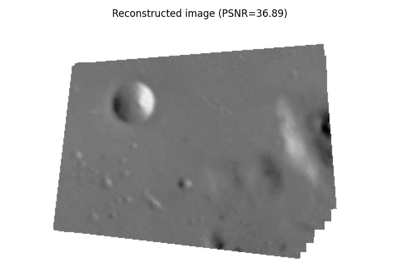

[Assemble images with simple image stitching](https://scikit-image.org/docs/0.26.x/auto_examples/registration/plot_stitching.html)

Assemble images with simple image stitching

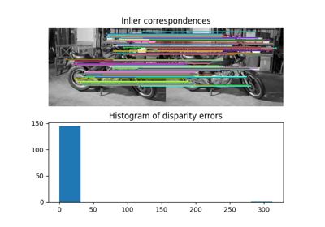

[Fundamental matrix estimation](https://scikit-image.org/docs/0.26.x/auto_examples/transform/plot_fundamental_matrix.html)

Fundamental matrix estimation

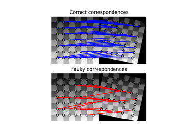

[Robust matching using RANSAC](https://scikit-image.org/docs/0.26.x/auto_examples/transform/plot_matching.html)

Robust matching using RANSAC

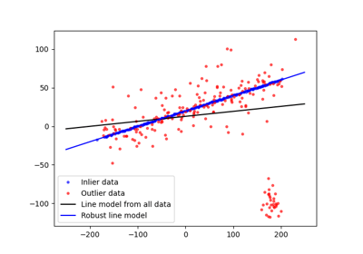

[Robust line model estimation using RANSAC](https://scikit-image.org/docs/0.26.x/auto_examples/transform/plot_ransac.html)

Robust line model estimation using RANSAC

**`skimage.measure.regionprops(label_image, intensity_image=None, cache=True, *, extra_properties=None, spacing=None, offset=None)` [[source]](https://github.com/scikit-image/scikit-image/blob/v0.26.0/skimage/measure/_regionprops.py#L1163-L1471)**

Measure properties of labeled image regions.

Region properties are evaluated on demand and come in diverse types. If you want to do tabular data analysis of specific properties, consider using `skimage.measure.regionprops_table()` instead.

**Parameters:**

**`label_image(M, N[, P]) ndarray`**

Label image. Labels with value 0 are ignored.

Changed in version 0.14.1: Previously, `label_image` was processed by `numpy.squeeze` and so any number of singleton dimensions was allowed. This resulted in inconsistent handling of images with singleton dimensions. To recover the old behaviour, use `regionprops(np.squeeze(label_image), ...)`.

**`intensity_image(M, N[, P][, C]) ndarray, optional`**

Intensity (input) image of same shape as label image, plus optionally an extra dimension for multichannel data. Currently, this extra channel dimension, if present, must be the last axis. Default is None.

Changed in version 0.18.0: The ability to provide an extra dimension for channels was added.

**`cachebool, optional`**

Determine whether to cache calculated properties. The computation is much faster for cached properties, whereas the memory consumption increases.

**`extra_propertiesiterable of callables`**

Add extra property computation functions that are not included with skimage. The name of the property is derived from the function name and its dtype is inferred by calling the function on a small sample. If the name of an extra property clashes with the name of an existing property, the extra property will not be visible and a UserWarning will be issued. A property computation function must take `label_image` as its first argument. If the property requires an intensity image, it must accept `intensity_image` as the second argument.

**`spacingtuple of float, shape (ndim,)`**

The pixel spacing along each axis of the image.

**`offsetarray-like of int, shape (label_image.ndim,), optional`**

Coordinates of the origin (“top-left” corner) of the label image. Normally this is ([0, ]0, 0), but it might be different if one wants to obtain regionprops of subvolumes within a larger volume.

**Returns:**

**`propertieslist of RegionProperties`**

Each item of the list corresponds to one labeled image region, and can be accessed using the attributes listed below.

See also

**`label`**

#### Notes

The following properties can be accessed as attributes or keys:

**`areafloat`**

Area of the region, i.e., number of pixels of the region scaled by pixel area (as determined by `spacing`).

**`area_bboxfloat`**

Area of the bounding box, i.e., number of pixels of the region’s bounding box scaled by pixel area (as determined by `spacing`).

**`area_convexfloat`**

Area of the convex hull image, which is the smallest convex polygon that encloses the region.

**`area_filledfloat`**

Area of the region with all the holes filled in.

**`axis_major_lengthfloat`**

The length of the major axis of the ellipse that has the same normalized second central moments as the region.

**`axis_minor_lengthfloat`**

The length of the minor axis of the ellipse that has the same normalized second central moments as the region.

**`bboxtuple`**

Bounding box `(min_row, min_col, max_row, max_col)`. Pixels belonging to the bounding box are in the half-open interval `[min_row; max_row)` and `[min_col; max_col)`.

**`centroidarray`**

Centroid coordinate tuple `(row, col)`.

**`centroid_localarray`**

Centroid coordinate tuple `(row, col)`, relative to region bounding box.

**`centroid_weightedarray`**

Centroid coordinate tuple `(row, col)` weighted with intensity image.

**`centroid_weighted_localarray`**

Centroid coordinate tuple `(row, col)`, relative to region bounding box, weighted with intensity image.

**`coords_scaled(K, 2) ndarray`**

Coordinate list `(row, col)` of the region scaled by `spacing`.

**`coords(K, 2) ndarray`**

Coordinate list `(row, col)` of the region.

**`eccentricityfloat`**

Eccentricity of the ellipse that has the same second moments as the region. The eccentricity is the ratio of the focal distance (distance between focal points) over the major axis length. The value is in the interval [0, 1). When it is 0, the ellipse becomes a circle.

**`equivalent_diameter_areafloat`**

The diameter of a circle with the same area as the region.

**`euler_numberint`**

Euler characteristic of the set of non-zero pixels. Computed as number of connected components subtracted by number of holes (input.ndim connectivity). In 3D, number of connected components plus number of holes subtracted by number of tunnels.

**`extentfloat`**

Ratio of pixels in the region to pixels in the total bounding box. Computed as `area / (rows * cols)`.

**`feret_diameter_maxfloat`**

Maximum Feret’s diameter computed as the longest distance between points around a region’s convex hull contour as determined by `find_contours` [5].

**`image(H, J) ndarray`**

Binary region image sliced by the bounding box.

**`image_convex(H, J) ndarray`**

Binary convex hull image sliced by bounding box.

**`image_filled(H, J) ndarray`**

Binary region image with filled holes sliced by bounding box.

**`image_intensity(H, J) ndarray`**

Intensity image sliced by bounding box.

**`inertia_tensorndarray`**

Inertia tensor of the region for the rotation around its mass.

**`inertia_tensor_eigvalstuple`**

The eigenvalues of the inertia tensor in decreasing order.

**`intensity_maxfloat`**

Value of greatest intensity in the region.

**`intensity_meanfloat`**

Average of intensity values in the region.

**`intensity_medianfloat`**

Value of median intensity in the region.

**`intensity_minfloat`**

Value of lowest intensity in the region.

**`intensity_stdfloat`**

Standard deviation of intensity values in the region.

**`labelint`**

The region’s label in the input label image.

**`moments(3, 3) ndarray`**

Spatial moments up to 3rd order:

```
m_ij = sum{ array(row, col) * row^i * col^j }
```

where the sum is over the `row, col` coordinates of the region.

**`moments_central(3, 3) ndarray`**

Central moments (translation invariant) up to 3rd order:

```
mu_ij = sum{ array(row, col) * (row - row_c)^i * (col - col_c)^j }
```

where the sum is over the `row, col` coordinates of the region, and `row_c` and `col_c` are the coordinates of the region’s centroid.

**`moments_hutuple`**

Hu moments (translation, scale and rotation invariant).

**`moments_normalized(3, 3) ndarray`**

Normalized moments (translation and scale invariant) up to 3rd order:

```
nu_ij = mu_ij / m_00^[(i+j)/2 + 1]
```

where `m_00` is the zeroth spatial moment.

**`moments_weighted(3, 3) array`**

Spatial moments of intensity image up to 3rd order:

```
wm_ij = sum{ array(row, col) * row^i * col^j }
```

where the sum is over the `row, col` coordinates of the region.

**`moments_weighted_central(3, 3) ndarray`**

Central moments (translation invariant) of intensity image up to 3rd order:

```
wmu_ij = sum{ array(row, col) * (row - row_c)^i * (col - col_c)^j }
```

where the sum is over the `row, col` coordinates of the region, and `row_c` and `col_c` are the coordinates of the region’s weighted centroid.

**`moments_weighted_hutuple`**

Hu moments (translation, scale and rotation invariant) of intensity image.

**`moments_weighted_normalized(3, 3) ndarray`**

Normalized moments (translation and scale invariant) of intensity image up to 3rd order:

```
wnu_ij = wmu_ij / wm_00^[(i+j)/2 + 1]
```

where `wm_00` is the zero-th spatial moment (intensity-weighted area).

**`num_pixelsint`**

Number of foreground pixels.

**`orientationfloat`**

Angle between the 0th axis (rows) and the major axis of the ellipse that has the same second moments as the region, ranging from $-\pi/2$ to $\pi/2$ counter-clockwise.

**`perimeterfloat`**

Perimeter of the region which approximates the contour as a line through the centers of border pixels using a 4-connectivity.

**`perimeter_croftonfloat`**

Perimeter of the region approximated by the Crofton formula in 4 directions.

**`slicetuple of slices`**

A slice to extract the region from the input image.

**`solidityfloat`**

Ratio of pixels in the region to pixels of the convex hull image.

`properties` also supports iteration, so that you can do:

```
for region in properties:
    print(region, properties[region])
```

#### References

[1]

Wilhelm Burger, Mark Burge. Principles of Digital Image Processing: Core Algorithms. Springer-Verlag, London, 2009.

[2]

B. Jähne. Digital Image Processing. Springer-Verlag, Berlin-Heidelberg, 6. edition, 2005.

[3]

T. H. Reiss. Recognizing Planar Objects Using Invariant Image Features, from Lecture notes in computer science, p. 676. Springer, Berlin, 1993.

[4]

https://en.wikipedia.org/wiki/Image_moment

[]

W. Pabst, E. Gregorová. Characterization of particles and particle systems, pp. 27-28. ICT Prague, 2007. https://old.vscht.cz/sil/keramika/Characterization_of_particles/CPPS%20_English%20version_.pdf

#### Examples

```
>>> import skimage as ski
>>> img = ski.util.img_as_ubyte(ski.data.coins()) > 110
>>> label_img = ski.measure.label(img, connectivity=img.ndim)
>>> props = ski.measure.regionprops(label_img)
>>> # centroid of first labeled region
>>> props[0].centroid
(22.72987986048314, 81.91228523446583)
>>> # centroid of first labeled region
>>> props[0]['centroid']
(22.72987986048314, 81.91228523446583)
```

Add custom measurements by passing functions as `extra_properties`:

```
>>> import numpy as np
>>> import skimage as ski
>>> img = ski.util.img_as_ubyte(ski.data.coins()) > 110
>>> label_img = ski.measure.label(img, connectivity=img.ndim)
>>> def pixelcount(regionmask):
...     return np.sum(regionmask)
>>> props = ski.measure.regionprops(label_img, extra_properties=(pixelcount,))
>>> # pixelcount of first labeled region
>>> props[0].pixelcount
7741
>>> # pixelcount of first labeled region
>>> props[1]['pixelcount']
42
```

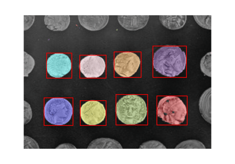

[Label image regions](https://scikit-image.org/docs/0.26.x/auto_examples/segmentation/plot_label.html)

Label image regions

[Measure region properties](https://scikit-image.org/docs/0.26.x/auto_examples/segmentation/plot_regionprops.html)

Measure region properties

**`skimage.measure.regionprops_table(label_image, intensity_image=None, properties=('label', 'bbox'), *, cache=True, separator='-', extra_properties=None, spacing=None)` [[source]](https://github.com/scikit-image/scikit-image/blob/v0.26.0/skimage/measure/_regionprops.py#L973-L1160)**

Compute region properties and return them as a pandas-compatible table.

The return value is a dictionary mapping property names to value arrays. This dictionary can be used as input to `pandas.DataFrame` to result in a “tidy” [1] table with one region per row and one property per column.

Use this function typically when you want to do downstream data analysis, or save region data to disk in a structured way. One downside of this function is that it breaks multi-dimensional properties into independent columns; for example, the region centroids of a 3D image end up in three different columns, one per dimension. If you need to do complex computations with the region properties, using `skimage.measure.regionprops()` might be more fitting.

Added in version 0.16.

**Parameters:**

**`label_image(M, N[, P]) ndarray`**

Label image. Labels with value 0 are ignored.

**`intensity_image(M, N[, P][, C]) ndarray, optional`**

Intensity (input) image of same shape as label image, plus optionally an extra dimension for multichannel data. The channel dimension, if present, must be the last axis. Default is None.

Changed in version 0.18.0: The ability to provide an extra dimension for channels was added.

**`propertiestuple or list of str, optional`**

Properties that will be included in the resulting dictionary For a list of available properties, please see `regionprops()`. Users should remember to add “label” to keep track of region identities.

**`cachebool, optional`**

Determine whether to cache calculated properties. The computation is much faster for cached properties, whereas the memory consumption increases.

**`separatorstr, optional`**

For non-scalar properties not listed in OBJECT_COLUMNS, each element will appear in its own column, with the index of that element separated from the property name by this separator. For example, the inertia tensor of a 2D region will appear in four columns: `inertia_tensor-0-0`, `inertia_tensor-0-1`, `inertia_tensor-1-0`, and `inertia_tensor-1-1` (where the separator is `-`).

Object columns are those that cannot be split in this way because the number of columns would change depending on the object. For example, `image` and `coords`.

**`extra_propertiesiterable of callables`**

Add extra property computation functions that are not included with skimage. The name of the property is derived from the function name, the dtype is inferred by calling the function on a small sample. If the name of an extra property clashes with the name of an existing property the extra property will not be visible and a UserWarning is issued. A property computation function must take a region mask as its first argument. If the property requires an intensity image, it must accept the intensity image as the second argument.

**`spacingtuple of float, shape (ndim,)`**

The pixel spacing along each axis of the image.

**Returns:**

**`out_dictdict`**

Dictionary mapping property names to an array of values of that property, one value per region. This dictionary can be used as input to pandas `DataFrame` to map property names to columns in the frame and regions to rows. If the image has no regions, the arrays will have length 0, but the correct type.

#### Notes

Each column contains either a scalar property, an object property, or an element in a multidimensional array.

Properties with scalar values for each region, such as “eccentricity”, will appear as a float or int array with that property name as key.

Multidimensional properties *of fixed size* for a given image dimension, such as “centroid” (every centroid will have three elements in a 3D image, no matter the region size), will be split into that many columns, with the name {property_name}{separator}{element_num} (for 1D properties), {property_name}{separator}{elem_num0}{separator}{elem_num1} (for 2D properties), and so on.

For multidimensional properties that don’t have a fixed size, such as “image” (the image of a region varies in size depending on the region size), an object array will be used, with the corresponding property name as the key.

#### References

[]

Wickham, H (2014) “Tidy Data” Journal of Statistical Software, 59(10), 1–23. https://doi.org/10.18637/jss.v059.i10 https://vita.had.co.nz/papers/tidy-data.pdf

#### Examples

```
>>> from skimage import data, util, measure
>>> image = data.coins()
>>> label_image = measure.label(image > 110, connectivity=image.ndim)
>>> props = measure.regionprops_table(label_image, image,
...                           properties=['label', 'inertia_tensor',
...                                       'inertia_tensor_eigvals'])
>>> props
{'label': array([ 1,  2, ...]), ...
 'inertia_tensor-0-0': array([  4.012...e+03,   8.51..., ...]), ...
 ...,
 'inertia_tensor_eigvals-1': array([  2.67...e+02,   2.83..., ...])}
```

The resulting dictionary can be directly passed to pandas, if installed, to obtain a clean DataFrame:

```
>>> import pandas as pd
>>> data = pd.DataFrame(props)
>>> data.head()
   label  inertia_tensor-0-0  ...  inertia_tensor_eigvals-1
0      1         4012.909888  ...                267.065503
1      2            8.514739  ...                  2.834806
2      3            0.666667  ...                  0.000000
3      4            0.000000  ...                  0.000000
4      5            0.222222  ...                  0.111111
```

[5 rows x 7 columns]

If we want to measure a feature that does not come as a built-in property, we can define custom functions and pass them as `extra_properties`. For example, we can create a custom function that measures the intensity quartiles in a region:

```
>>> from skimage import data, util, measure
>>> import numpy as np
>>> def quartiles(regionmask, intensity):
...     return np.percentile(intensity[regionmask], q=(25, 50, 75))
>>>
>>> image = data.coins()
>>> label_image = measure.label(image > 110, connectivity=image.ndim)
>>> props = measure.regionprops_table(label_image, intensity_image=image,
...                                   properties=('label',),
...                                   extra_properties=(quartiles,))
>>> import pandas as pd
>>> pd.DataFrame(props).head()
       label  quartiles-0  quartiles-1  quartiles-2
0      1       117.00        123.0        130.0
1      2       111.25        112.0        114.0
2      3       111.00        111.0        111.0
3      4       111.00        111.5        112.5
4      5       112.50        113.0        114.0
```

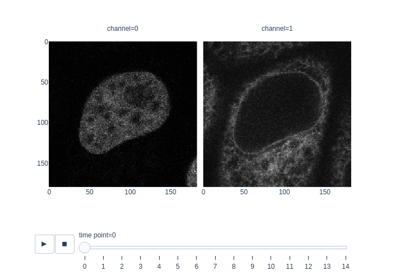

[Measure fluorescence intensity at the nuclear envelope](https://scikit-image.org/docs/0.26.x/auto_examples/applications/plot_fluorescence_nuclear_envelope.html)

Measure fluorescence intensity at the nuclear envelope

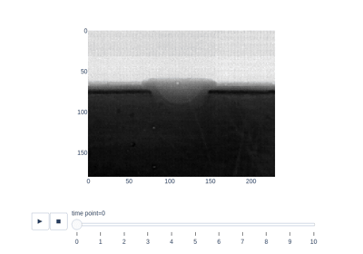

[Track solidification of a metallic alloy](https://scikit-image.org/docs/0.26.x/auto_examples/applications/plot_solidification_tracking.html)

Track solidification of a metallic alloy

[Measure region properties](https://scikit-image.org/docs/0.26.x/auto_examples/segmentation/plot_regionprops.html)

Measure region properties

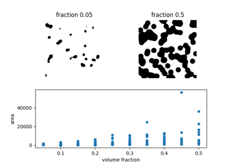

[Explore and visualize region properties with pandas](https://scikit-image.org/docs/0.26.x/auto_examples/segmentation/plot_regionprops_table.html)

Explore and visualize region properties with pandas

**`skimage.measure.shannon_entropy(image, base=2)` [[source]](https://github.com/scikit-image/scikit-image/blob/v0.26.0/skimage/measure/entropy.py#L5-L41)**

Calculate the Shannon entropy of an image.

The Shannon entropy is defined as S = -sum(pk * log(pk)), where pk are frequency/probability of pixels of value k.

**Parameters:**

**`image(M, N) ndarray`**

Grayscale input image.

**`basefloat, optional`**

The logarithmic base to use.

**Returns:**

**`entropyfloat`**

#### Notes

The returned value is measured in bits or shannon (Sh) for base=2, natural unit (nat) for base=np.e and hartley (Hart) for base=10.

#### References

[1]

https://en.wikipedia.org/wiki/Entropy_(information_theory)

[2]

https://en.wiktionary.org/wiki/Shannon_entropy

#### Examples

```
>>> from skimage import data
>>> from skimage.measure import shannon_entropy
>>> shannon_entropy(data.camera())
7.231695011055706
```

**`skimage.measure.subdivide_polygon(coords, degree=2, preserve_ends=False)` [[source]](https://github.com/scikit-image/scikit-image/blob/v0.26.0/skimage/measure/_polygon.py#L108-L168)**

Subdivision of polygonal curves using B-Splines.

Note that the resulting curve is always within the convex hull of the original polygon. Circular polygons stay closed after subdivision.

**Parameters:**

**`coords(K, 2) array`**

Coordinate array.

**`degree{1, 2, 3, 4, 5, 6, 7}, optional`**

Degree of B-Spline. Default is 2.

**`preserve_endsbool, optional`**

Preserve first and last coordinate of non-circular polygon. Default is False.

**Returns:**

**`coords(L, 2) array`**

Subdivided coordinate array.

#### References

[1]

http://mrl.nyu.edu/publications/subdiv-course2000/coursenotes00.pdf

[Approximate and subdivide polygons](https://scikit-image.org/docs/0.26.x/auto_examples/edges/plot_polygon.html)

Approximate and subdivide polygons

**`class skimage.measure.CircleModel(center, radius)` [[source]](https://github.com/scikit-image/scikit-image/blob/v0.26.0/skimage/measure/fit.py#L454-L704)**

Bases: `_BaseModel`

Total least squares estimator for 2D circles.

The functional model of the circle is:

```
r**2 = (x - xc)**2 + (y - yc)**2
```

This estimator minimizes the squared distances from all points to the circle:

```
min{ sum((r - sqrt((x_i - xc)**2 + (y_i - yc)**2))**2) }
```

A minimum number of 3 points is required to solve for the parameters.

**Parameters:**

**`centerarray-like, shape (2,)`**

Coordinates of circle center.

**`radiusfloat`**

Circle radius.

**Raises:**

**ValueError**

If `center` does not have length 2.

#### Notes

The estimation is carried out using a 2D version of the spherical estimation given in [1].

#### References

[]

Jekel, Charles F. Obtaining non-linear orthotropic material models for pvc-coated polyester via inverse bubble inflation. Thesis (MEng), Stellenbosch University, 2016. Appendix A, pp. 83-87. https://hdl.handle.net/10019.1/98627

#### Examples

```
>>> t = np.linspace(0, 2 * np.pi, 25)
>>> xy = CircleModel((2, 3), 4).predict_xy(t)
>>> model = CircleModel.from_estimate(xy)
>>> model.center
array([2., 3.])
>>> model.radius
4.0
>>> res = model.residuals(xy)
>>> np.abs(np.round(res, 9))
array([0., 0., 0., 0., 0., 0., 0., 0., 0., 0., 0., 0., 0., 0., 0., 0., 0.,
       0., 0., 0., 0., 0., 0., 0., 0.])
```

The estimation can fail when — for example — all the input or output points are the same. If this happens, you will get a transform that is not “truthy” - meaning that `bool(tform)` is `False`:

```
>>> # A successfully estimated model is truthy:
>>> if model:
...     print("Estimation succeeded.")
Estimation succeeded.
>>> # Not so for a degenerate model with identical points.
>>> bad_data = np.ones((4, 2))
>>> bad_model = CircleModel.from_estimate(bad_data)
>>> if not bad_model:
...     print("Estimation failed.")
Estimation failed.
```

Trying to use this failed estimation transform result will give a suitable error:

```
>>> bad_model.residuals(xy)
Traceback (most recent call last):
  ...
FailedEstimationAccessError: No attribute "residuals" for failed estimation ...
```

**`__init__(center, radius)` [[source]](https://github.com/scikit-image/scikit-image/blob/v0.26.0/skimage/measure/fit.py#L132-L146)**

**`estimate(data)` [[source]](https://github.com/scikit-image/scikit-image/blob/v0.26.0/skimage/measure/fit.py#L689-L704)**

**Deprecated:** `estimate` is deprecated since version 0.26 and will be removed in version 2.2. Please use `CircleModel.from_estimate` class constructor instead.

Estimate circle model from data using total least squares.

**Parameters:**

**`data(N, 2) array`**

N points with `(x, y)` coordinates, respectively.

**Returns:**

**`successbool`**

True, if model estimation succeeds.

**`classmethod from_estimate(data)` [[source]](https://github.com/scikit-image/scikit-image/blob/v0.26.0/skimage/measure/fit.py#L565-L588)**

Estimate circle model from data using total least squares.

**Parameters:**

**`data(N, 2) array`**

N points with `(x, y)` coordinates, respectively.

**Returns:**

**`modelSelf or FailedEstimation`**

An instance of the circle model if the estimation succeeded. Otherwise, we return a special `FailedEstimation` object to signal a failed estimation. Testing the truth value of the failed estimation object will return `False`. E.g.

```
model = CircleModel.from_estimate(...)
if not model:
    raise RuntimeError(f"Failed estimation: {model}")
```

**`property params`**

**Deprecated:** `params` is deprecated since version 0.26 and will be removed in version 2.2. `params` attribute deprecated; use `center, radius` attributes instead.

Return model attributes `center, radius` as 1D array.

**`predict_xy(t, params=<DEPRECATED>)` [[source]](https://github.com/scikit-image/scikit-image/blob/v0.26.0/skimage/measure/fit.py#L659-L687)**

Predict x- and y-coordinates using the estimated model.

**Parameters:**

**`tarray-like`**

Angles in circle in radians. Angles start to count from positive x-axis to positive y-axis in a right-handed system.

**Returns:**

**`xy(…, 2) array`**

Predicted x- and y-coordinates.

**Other Parameters:**

**`paramsDEPRECATED, optional`**

Optional parameters `xc`, `yc`, `radius`.

Deprecated since version 0.26.

**`residuals(data)` [[source]](https://github.com/scikit-image/scikit-image/blob/v0.26.0/skimage/measure/fit.py#L632-L657)**

Determine residuals of data to model.

For each point the shortest distance to the circle is returned.

**Parameters:**

**`data(N, 2) array`**

N points with `(x, y)` coordinates, respectively.

**Returns:**

**`residuals(N,) array`**

Residual for each data point.

**`class skimage.measure.EllipseModel(center, axis_lengths, theta)` [[source]](https://github.com/scikit-image/scikit-image/blob/v0.26.0/skimage/measure/fit.py#L707-L1089)**

Bases: `_BaseModel`

Total least squares estimator for 2D ellipses.

The functional model of the ellipse is:

```
xt = xc + a*cos(theta)*cos(t) - b*sin(theta)*sin(t)
yt = yc + a*sin(theta)*cos(t) + b*cos(theta)*sin(t)
d = sqrt((x - xt)**2 + (y - yt)**2)
```

where `(xt, yt)` is the closest point on the ellipse to `(x, y)`. Thus d is the shortest distance from the point to the ellipse.

The estimator is based on a least squares minimization. The optimal solution is computed directly, no iterations are required. This leads to a simple, stable and robust fitting method.

**Parameters:**

**`centerarray-like, shape (2,)`**

Coordinates of ellipse center.

**`axis_lengthsarray-like, shape (2,)`**

Length of first axis and length of second axis. Call these `a` and `b`.

**`thetafloat`**

Angle of first axis.

**Raises:**

**ValueError**

If `center` does not have length 2.

#### Examples

```
>>> em = EllipseModel((10, 15), (8, 4), np.deg2rad(30))
>>> xy = em.predict_xy(np.linspace(0, 2 * np.pi, 25))
>>> ellipse = EllipseModel.from_estimate(xy)
>>> ellipse.center
array([10., 15.])
>>> ellipse.axis_lengths
array([8., 4.])
>>> round(ellipse.theta, 2)
0.52
>>> np.round(abs(ellipse.residuals(xy)), 5)
array([0., 0., 0., 0., 0., 0., 0., 0., 0., 0., 0., 0., 0., 0., 0., 0., 0.,
       0., 0., 0., 0., 0., 0., 0., 0.])
```

The estimation can fail when — for example — all the input or output points are the same. If this happens, you will get an ellipse model for which `bool(model)` is `False`:

```
>>> # A successfully estimated model is truthy:
>>> if ellipse:
...     print("Estimation succeeded.")
Estimation succeeded.
>>> # Not so for a degenerate model with identical points.
>>> bad_data = np.ones((4, 2))
>>> bad_ellipse = EllipseModel.from_estimate(bad_data)
>>> if not bad_ellipse:
...     print("Estimation failed.")
Estimation failed.
```

Trying to use this failed estimation transform result will give a suitable error:

```
>>> bad_ellipse.residuals(xy)
Traceback (most recent call last):
  ...
FailedEstimationAccessError: No attribute "residuals" for failed estimation ...
```

**`__init__(center, axis_lengths, theta)` [[source]](https://github.com/scikit-image/scikit-image/blob/v0.26.0/skimage/measure/fit.py#L132-L146)**

**`estimate(data)` [[source]](https://github.com/scikit-image/scikit-image/blob/v0.26.0/skimage/measure/fit.py#L1066-L1089)**

**Deprecated:** `estimate` is deprecated since version 0.26 and will be removed in version 2.2. Please use `EllipseModel.from_estimate` class constructor instead.

Estimate ellipse model from data using total least squares.

**Parameters:**

**`data(N, 2) array`**

N points with `(x, y)` coordinates, respectively.

**Returns:**

**`successbool`**

True, if model estimation succeeds.

**`classmethod from_estimate(data)` [[source]](https://github.com/scikit-image/scikit-image/blob/v0.26.0/skimage/measure/fit.py#L820-L851)**

Estimate ellipse model from data using total least squares.

**Parameters:**

**`data(N, 2) array`**

N points with `(x, y)` coordinates, respectively.

**Returns:**

**`modelSelf or FailedEstimation`**

An instance of the ellipse model if the estimation succeeded. Otherwise, we return a special `FailedEstimation` object to signal a failed estimation. Testing the truth value of the failed estimation object will return `False`. E.g.

```
model = EllipseModel.from_estimate(...)
if not model:
    raise RuntimeError(f"Failed estimation: {model}")
```

#### References

[1]

Halir, R.; Flusser, J. “Numerically stable direct least squares fitting of ellipses”. In Proc. 6th International Conference in Central Europe on Computer Graphics and Visualization. WSCG (Vol. 98, pp. 125-132).

**`property params`**

**Deprecated:** `params` is deprecated since version 0.26 and will be removed in version 2.2. `params` attribute deprecated; use `center, axis_lengths, theta` attributes instead.

Return model attributes `center, axis_lengths, theta` as 1D array.

**`predict_xy(t, params=<DEPRECATED>)` [[source]](https://github.com/scikit-image/scikit-image/blob/v0.26.0/skimage/measure/fit.py#L1030-L1064)**

Predict x- and y-coordinates using the estimated model.

**Parameters:**

**`tarray`**

Angles in circle in radians. Angles start to count from positive x-axis to positive y-axis in a right-handed system.

**Returns:**

**`xy(…, 2) array`**

Predicted x- and y-coordinates.

**Other Parameters:**

**`paramsDEPRECATED, optional`**

Optional ellipse model parameters in the following order `xc`, `yc`, `a`, `b`, `theta`.

Deprecated since version 0.26.

**`residuals(data)` [[source]](https://github.com/scikit-image/scikit-image/blob/v0.26.0/skimage/measure/fit.py#L966-L1028)**

Determine residuals of data to model.

For each point the shortest distance to the ellipse is returned.

**Parameters:**

**`data(N, 2) array`**

N points with `(x, y)` coordinates, respectively.

**Returns:**

**`residuals(N,) array`**

Residual for each data point.

**`class skimage.measure.LineModelND(origin, direction)` [[source]](https://github.com/scikit-image/scikit-image/blob/v0.26.0/skimage/measure/fit.py#L165-L451)**

Bases: `_BaseModel`

Total least squares estimator for N-dimensional lines.

In contrast to ordinary least squares line estimation, this estimator minimizes the orthogonal distances of points to the estimated line.

Lines are defined by a point (origin) and a unit vector (direction) according to the following vector equation:

```
X = origin + lambda * direction
```

**Parameters:**

**`originarray-like, shape (N,)`**

Coordinates of line origin in N dimensions.

**`directionarray-like, shape (N,)`**

Vector giving line direction.

**Raises:**

**ValueError**

If length of `origin` and `direction` differ.

#### Examples

```
>>> x = np.linspace(1, 2, 25)
>>> y = 1.5 * x + 3
>>> lm = LineModelND.from_estimate(np.stack([x, y], axis=-1))
>>> lm.origin
array([1.5 , 5.25])
>>> lm.direction
array([0.5547 , 0.83205])
>>> res = lm.residuals(np.stack([x, y], axis=-1))
>>> np.abs(np.round(res, 9))
array([0., 0., 0., 0., 0., 0., 0., 0., 0., 0., 0., 0., 0., 0., 0., 0., 0.,
       0., 0., 0., 0., 0., 0., 0., 0.])
>>> np.round(lm.predict_y(x[:5]), 3)
array([4.5  , 4.562, 4.625, 4.688, 4.75 ])
>>> np.round(lm.predict_x(y[:5]), 3)
array([1.   , 1.042, 1.083, 1.125, 1.167])
```

**`__init__(origin, direction)` [[source]](https://github.com/scikit-image/scikit-image/blob/v0.26.0/skimage/measure/fit.py#L132-L146)**

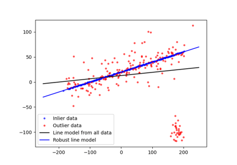

[Robust line model estimation using RANSAC](https://scikit-image.org/docs/0.26.x/auto_examples/transform/plot_ransac.html)

Robust line model estimation using RANSAC

**`estimate(data)` [[source]](https://github.com/scikit-image/scikit-image/blob/v0.26.0/skimage/measure/fit.py#L434-L451)**

**Deprecated:** `estimate` is deprecated since version 0.26 and will be removed in version 2.2. Please use `LineModelND.from_estimate` class constructor instead.

Estimate line model from data.

This minimizes the sum of shortest (orthogonal) distances from the given data points to the estimated line.

**Parameters:**

**`data(N, dim) array`**

N points in a space of dimensionality `dim >= 2`.

**Returns:**

**`successbool`**

True, if model estimation succeeds.

**`classmethod from_estimate(data)` [[source]](https://github.com/scikit-image/scikit-image/blob/v0.26.0/skimage/measure/fit.py#L242-L268)**

Estimate line model from data.

This minimizes the sum of shortest (orthogonal) distances from the given data points to the estimated line.

**Parameters:**

**`data(N, dim) array`**

N points in a space of dimensionality dim >= 2.

**Returns:**

**`modelSelf or FailedEstimation`**

An instance of the line model if the estimation succeeded. Otherwise, we return a special `FailedEstimation` object to signal a failed estimation. Testing the truth value of the failed estimation object will return `False`. E.g.

```
model = LineModelND.from_estimate(...)
if not model:
    raise RuntimeError(f"Failed estimation: {model}")
```

**`property params`**

**Deprecated:** `params` is deprecated since version 0.26 and will be removed in version 2.2. `params` attribute deprecated; use `origin, direction` attributes instead.

Return model attributes as `origin, direction` tuple.

**`predict(x, axis=0, params=<DEPRECATED>)` [[source]](https://github.com/scikit-image/scikit-image/blob/v0.26.0/skimage/measure/fit.py#L327-L362)**

Predict intersection of line model with orthogonal hyperplane.

**Parameters:**

**`x(n, 1) array`**

Coordinates along an axis.

**`axisint`**

Axis orthogonal to the hyperplane intersecting the line.

**Returns:**

**`data(n, m) array`**

Predicted coordinates.

**Other Parameters:**

**`paramsDEPRECATED, optional`**

Optional custom parameter set in the form (`origin`, `direction`).

Deprecated since version 0.26.

**Raises:**

**ValueError**

If the line is parallel to the given axis.

**`predict_x(y, params=<DEPRECATED>)` [[source]](https://github.com/scikit-image/scikit-image/blob/v0.26.0/skimage/measure/fit.py#L364-L397)**

Predict x-coordinates for 2D lines using the estimated model.

Alias for:

```
predict(y, axis=1)[:, 0]
```

**Parameters:**

**`yarray`**

y-coordinates.

**Returns:**

**`xarray`**

Predicted x-coordinates.

**Other Parameters:**

**`paramsDEPRECATED, optional`**

Optional custom parameter set in the form (`origin`, `direction`).

Deprecated since version 0.26.

**`predict_y(x, params=<DEPRECATED>)` [[source]](https://github.com/scikit-image/scikit-image/blob/v0.26.0/skimage/measure/fit.py#L399-L432)**

Predict y-coordinates for 2D lines using the estimated model.

Alias for:

```
predict(x, axis=0)[:, 1]
```

**Parameters:**

**`xarray`**

x-coordinates.

**Returns:**

**`yarray`**

Predicted y-coordinates.

**Other Parameters:**

**`paramsDEPRECATED, optional`**

Optional custom parameter set in the form (`origin`, `direction`).

Deprecated since version 0.26.

**`residuals(data, params=<DEPRECATED>)` [[source]](https://github.com/scikit-image/scikit-image/blob/v0.26.0/skimage/measure/fit.py#L292-L325)**

Determine residuals of data to model.

For each point, the shortest (orthogonal) distance to the line is returned. It is obtained by projecting the data onto the line.

**Parameters:**

**`data(N, dim) array`**

N points in a space of dimension dim.

**Returns:**

**`residuals(N,) array`**

Residual for each data point.

**Other Parameters:**

**`paramsDEPRECATED, optional`**

Optional custom parameter set in the form (`origin`, `direction`).

Deprecated since version 0.26.

**`class skimage.measure.RansacModelProtocol(*args, **kwargs)` [[source]](https://github.com/scikit-image/scikit-image/blob/v0.26.0/skimage/measure/fit.py#L31-L38)**

Bases: [`Protocol`](https://docs.python.org/3/library/typing.html#typing.Protocol)

Protocol for `ransac` model class.

**`__init__(*args, **kwargs)` [[source]](https://github.com/scikit-image/scikit-image/blob/v0.26.0/skimage/../../typing.py#L1770-L1796)**

**`classmethod from_estimate(*data)` [[source]](https://github.com/scikit-image/scikit-image/blob/v0.26.0/skimage/measure/fit.py#L35-L36)**

**`residuals(*data)` [[source]](https://github.com/scikit-image/scikit-image/blob/v0.26.0/skimage/measure/fit.py#L38-L38)**

© 2019 the scikit-image team  
Licensed under the BSD 3-clause License.  
https://scikit-image.org/docs/0.26.x/api/skimage.measure.html